# Group 1: BASS

```python
import os
import pandas as pd
import matplotlib.pyplot as plt
from ipywidgets import widgets, interactive, Layout
import seaborn
import numpy as np
```

# Partisan Analysis

load files for analysis

```python
dfu=pd.read_csv("files/stateunemp.csv")
dfu
```

|  | Area | 1980 | 1981 | 1982 | 1983 | 1984 | 1985 | 1986 | 1987 | 1988 | ... | 2009 | 2010 | 2011 | 2012 | 2013 | 2014 | 2015 | 2016 | 2017 | 2018 |
| --- | --- | --- | --- | --- | --- | --- | --- | --- | --- | --- | --- | --- | --- | --- | --- | --- | --- | --- | --- | --- | --- |
| 0 | United States | 7.1 | 7.6 | 9.7 | 9.6 | 7.5 | 7.2 | 7.0 | 6.2 | 5.5 | ... | 9.3 | 9.6 | 8.9 | 8.1 | 7.4 | 6.2 | 5.3 | 4.9 | 4.4 | 3.9 |
| 1 | Alabama | 8.9 | 10.6 | 14.1 | 13.8 | 11.0 | 9.2 | 9.7 | 8.1 | 7.2 | ... | 11.0 | 10.5 | 9.6 | 8.0 | 7.2 | 6.8 | 6.1 | 5.8 | 4.4 | 3.9 |
| 2 | Alaska | 9.6 | 9.4 | 9.9 | 9.9 | 9.8 | 9.7 | 10.9 | 10.3 | 8.8 | ... | 7.7 | 7.9 | 7.6 | 7.1 | 7.0 | 6.9 | 6.5 | 6.9 | 7.0 | 6.6 |
| 3 | Arizona | 6.6 | 6.2 | 10.1 | 8.8 | 5.2 | 6.3 | 6.9 | 6.5 | 6.4 | ... | 9.9 | 10.4 | 9.5 | 8.3 | 7.7 | 6.8 | 6.1 | 5.4 | 4.9 | 4.8 |
| 4 | Arkansas | 7.6 | 8.7 | 9.9 | 9.9 | 8.7 | 8.7 | 8.6 | 8.1 | 7.6 | ... | 7.8 | 8.2 | 8.3 | 7.6 | 7.2 | 6.0 | 5.0 | 4.0 | 3.7 | 3.7 |
| 5 | California | 6.8 | 7.4 | 10.0 | 9.8 | 7.8 | 7.2 | 6.7 | 5.8 | 5.3 | ... | 11.2 | 12.2 | 11.7 | 10.4 | 8.9 | 7.5 | 6.2 | 5.5 | 4.8 | 4.2 |
| 6 | Colorado | 5.8 | 5.7 | 7.3 | 7.1 | 5.4 | 6.1 | 7.5 | 7.5 | 6.5 | ... | 7.3 | 8.7 | 8.4 | 7.9 | 6.9 | 5.0 | 3.9 | 3.2 | 2.7 | 3.3 |
| 7 | Connecticut | 5.8 | 6.2 | 6.9 | 6.0 | 4.7 | 4.7 | 3.8 | 3.4 | 3.0 | ... | 7.9 | 9.1 | 8.8 | 8.3 | 7.8 | 6.6 | 5.7 | 5.1 | 4.7 | 4.1 |
| 8 | Delaware | 7.6 | 7.8 | 8.4 | 7.7 | 6.3 | 5.1 | 4.3 | 3.1 | 3.1 | ... | 8.3 | 8.4 | 7.5 | 7.2 | 6.7 | 5.7 | 4.9 | 4.5 | 4.5 | 3.8 |
| 9 | District of Columbia | 7.4 | 8.9 | 10.4 | 11.2 | 9.1 | 8.1 | 7.5 | 6.3 | 5.0 | ... | 9.3 | 9.4 | 10.2 | 9.0 | 8.5 | 7.8 | 6.9 | 6.1 | 6.1 | 5.6 |
| 10 | Florida | 6.1 | 6.7 | 8.4 | 8.5 | 6.4 | 6.0 | 5.8 | 5.3 | 5.1 | ... | 10.4 | 11.1 | 10.0 | 8.5 | 7.2 | 6.3 | 5.5 | 4.8 | 4.2 | 3.6 |
| 11 | Georgia | 6.3 | 6.4 | 7.8 | 7.7 | 6.1 | 6.4 | 6.0 | 5.7 | 5.7 | ... | 9.9 | 10.5 | 10.2 | 9.2 | 8.2 | 7.1 | 6.0 | 5.4 | 4.7 | 3.9 |
| 12 | Hawaii | 5.0 | 5.4 | 6.3 | 6.2 | 5.7 | 5.4 | 4.8 | 3.8 | 3.2 | ... | 7.2 | 6.9 | 6.8 | 6.0 | 4.9 | 4.4 | 3.6 | 3.0 | 2.4 | 2.4 |
| 13 | Idaho | 7.5 | 7.7 | 9.9 | 8.9 | 7.3 | 7.9 | 8.4 | 7.6 | 6.0 | ... | 8.8 | 9.0 | 8.3 | 7.2 | 6.1 | 4.8 | 4.2 | 3.8 | 3.2 | 2.8 |
| 14 | Illinois | 8.2 | 8.5 | 11.4 | 11.8 | 9.0 | 9.1 | 8.3 | 7.4 | 6.7 | ... | 10.2 | 10.4 | 9.7 | 9.0 | 9.0 | 7.1 | 6.0 | 5.8 | 4.9 | 4.3 |
| 15 | Indiana | 9.6 | 9.9 | 12.0 | 11.2 | 8.6 | 7.8 | 6.9 | 6.2 | 5.2 | ... | 10.3 | 10.4 | 9.1 | 8.3 | 7.7 | 6.0 | 4.8 | 4.4 | 3.6 | 3.4 |
| 16 | Iowa | 6.0 | 6.6 | 8.5 | 8.1 | 7.0 | 7.5 | 6.8 | 5.5 | 4.5 | ... | 6.4 | 6.0 | 5.5 | 5.0 | 4.7 | 4.2 | 3.8 | 3.6 | 3.1 | 2.5 |
| 17 | Kansas | 4.4 | 4.3 | 6.3 | 5.9 | 4.9 | 5.1 | 5.3 | 4.8 | 4.5 | ... | 6.9 | 7.1 | 6.5 | 5.7 | 5.3 | 4.5 | 4.2 | 4.0 | 3.7 | 3.4 |
| 18 | Kentucky | 8.0 | 8.6 | 10.8 | 11.4 | 9.3 | 9.2 | 9.4 | 8.5 | 7.6 | ... | 10.3 | 10.2 | 9.4 | 8.2 | 8.0 | 6.5 | 5.3 | 5.1 | 4.9 | 4.3 |
| 19 | Louisiana | 6.9 | 8.4 | 10.3 | 11.5 | 10.1 | 11.6 | 12.8 | 12.1 | 10.8 | ... | 6.8 | 8.0 | 7.8 | 7.1 | 6.7 | 6.4 | 6.3 | 6.1 | 5.1 | 4.9 |
| 20 | Maine | 7.6 | 7.4 | 8.4 | 8.3 | 6.2 | 5.5 | 5.3 | 4.4 | 3.6 | ... | 8.1 | 8.1 | 7.9 | 7.5 | 6.6 | 5.6 | 4.4 | 3.8 | 3.4 | 3.4 |
| 21 | Maryland | 6.6 | 7.3 | 8.3 | 7.0 | 5.4 | 4.6 | 4.6 | 4.4 | 4.3 | ... | 7.0 | 7.7 | 7.2 | 7.0 | 6.6 | 5.8 | 5.1 | 4.5 | 4.3 | 3.9 |
| 22 | Massachusetts | 5.6 | 6.5 | 7.7 | 6.8 | 4.8 | 4.0 | 3.9 | 3.2 | 3.3 | ... | 8.1 | 8.3 | 7.3 | 6.7 | 6.7 | 5.7 | 4.8 | 3.9 | 3.8 | 3.3 |
| 23 | Michigan | 12.3 | 12.4 | 15.4 | 14.4 | 11.2 | 10.0 | 8.8 | 8.3 | 7.5 | ... | 13.7 | 12.6 | 10.4 | 9.1 | 8.8 | 7.2 | 5.4 | 5.0 | 4.6 | 4.1 |
| 24 | Minnesota | 5.8 | 5.8 | 7.9 | 8.0 | 6.3 | 6.0 | 5.5 | 5.1 | 4.3 | ... | 7.8 | 7.4 | 6.5 | 5.6 | 5.0 | 4.2 | 3.7 | 3.9 | 3.4 | 2.9 |
| 25 | Mississippi | 7.4 | 8.5 | 11.1 | 12.1 | 10.5 | 10.4 | 11.4 | 10.0 | 8.4 | ... | 9.5 | 10.4 | 10.0 | 9.0 | 8.5 | 7.5 | 6.4 | 5.8 | 5.1 | 4.8 |
| 26 | Missouri | 7.2 | 7.6 | 9.2 | 9.9 | 7.2 | 6.5 | 6.2 | 6.3 | 5.7 | ... | 9.3 | 9.6 | 8.5 | 6.9 | 6.7 | 6.1 | 5.0 | 4.6 | 3.8 | 3.2 |
| 27 | Montana | 6.1 | 6.8 | 8.5 | 8.6 | 7.6 | 7.7 | 7.9 | 7.4 | 6.6 | ... | 6.8 | 7.3 | 6.9 | 6.0 | 5.4 | 4.7 | 4.2 | 4.1 | 3.9 | 3.7 |
| 28 | Nebraska | 3.9 | 4.2 | 5.6 | 5.6 | 4.5 | 5.2 | 5.0 | 4.4 | 3.6 | ... | 4.6 | 4.6 | 4.4 | 4.0 | 3.8 | 3.3 | 3.0 | 3.1 | 2.9 | 2.8 |
| 29 | Nevada | 6.2 | 7.2 | 9.9 | 9.6 | 7.9 | 7.7 | 6.2 | 6.1 | 5.2 | ... | 11.3 | 13.5 | 13.0 | 11.2 | 9.6 | 7.9 | 6.8 | 5.7 | 5.1 | 4.6 |
| 30 | New Hampshire | 4.5 | 5.2 | 6.8 | 5.5 | 4.3 | 3.7 | 2.8 | 2.3 | 2.4 | ... | 6.2 | 5.8 | 5.4 | 5.5 | 5.1 | 4.3 | 3.4 | 2.9 | 2.7 | 2.5 |
| 31 | New Jersey | 7.2 | 7.4 | 8.7 | 8.0 | 6.2 | 5.6 | 5.0 | 4.1 | 3.8 | ... | 9.1 | 9.5 | 9.3 | 9.3 | 8.2 | 6.8 | 5.8 | 5.0 | 4.6 | 4.1 |
| 32 | New Mexico | 7.6 | 7.3 | 9.2 | 9.7 | 7.8 | 8.3 | 9.3 | 8.7 | 7.5 | ... | 7.5 | 8.1 | 7.5 | 7.1 | 6.9 | 6.7 | 6.5 | 6.6 | 5.9 | 4.9 |
| 33 | New York | 7.5 | 7.6 | 8.5 | 8.7 | 7.2 | 6.6 | 6.2 | 4.9 | 4.3 | ... | 8.3 | 8.6 | 8.3 | 8.5 | 7.7 | 6.3 | 5.3 | 4.9 | 4.7 | 4.1 |
| 34 | North Carolina | 6.4 | 6.5 | 9.2 | 9.0 | 6.7 | 5.6 | 5.3 | 4.5 | 3.6 | ... | 10.6 | 10.9 | 10.3 | 9.3 | 8.0 | 6.3 | 5.7 | 5.1 | 4.5 | 3.9 |
| 35 | North Dakota | 4.9 | 4.8 | 5.6 | 5.7 | 5.3 | 5.7 | 5.9 | 5.0 | 4.7 | ... | 4.1 | 3.8 | 3.5 | 3.1 | 2.9 | 2.7 | 2.8 | 3.1 | 2.7 | 2.6 |
| 36 | Ohio | 8.4 | 9.4 | 12.7 | 12.4 | 9.5 | 8.9 | 8.3 | 7.1 | 6.0 | ... | 10.3 | 10.3 | 8.8 | 7.4 | 7.5 | 5.8 | 4.9 | 5.0 | 5.0 | 4.6 |
| 37 | Oklahoma | 4.4 | 3.6 | 6.0 | 8.4 | 7.1 | 7.2 | 8.2 | 7.3 | 6.4 | ... | 6.4 | 6.8 | 5.9 | 5.2 | 5.3 | 4.5 | 4.4 | 4.8 | 4.2 | 3.4 |
| 38 | Oregon | 8.5 | 9.8 | 11.5 | 10.8 | 9.4 | 8.8 | 8.0 | 6.3 | 5.8 | ... | 11.3 | 10.6 | 9.5 | 8.8 | 7.9 | 6.8 | 5.6 | 4.8 | 4.1 | 4.2 |
| 39 | Pennsylvania | 8.0 | 8.4 | 11.2 | 11.5 | 9.1 | 8.0 | 6.9 | 5.6 | 5.0 | ... | 8.0 | 8.5 | 7.9 | 7.8 | 7.4 | 5.9 | 5.3 | 5.4 | 4.9 | 4.3 |
| 40 | Rhode Island | 7.2 | 7.8 | 9.7 | 8.3 | 5.5 | 4.6 | 4.1 | 3.6 | 3.1 | ... | 11.0 | 11.2 | 11.0 | 10.4 | 9.3 | 7.7 | 6.0 | 5.2 | 4.4 | 4.1 |
| 41 | South Carolina | 6.7 | 8.1 | 11.1 | 9.9 | 6.9 | 6.9 | 6.4 | 5.5 | 4.7 | ... | 11.2 | 11.2 | 10.6 | 9.2 | 7.6 | 6.5 | 6.0 | 5.0 | 4.3 | 3.4 |
| 42 | South Dakota | 4.8 | 5.0 | 5.5 | 5.2 | 4.4 | 4.8 | 4.6 | 4.2 | 4.1 | ... | 4.9 | 5.0 | 4.7 | 4.3 | 3.8 | 3.4 | 3.1 | 3.0 | 3.2 | 3.0 |
| 43 | Tennessee | 7.4 | 9.0 | 11.7 | 11.5 | 8.5 | 7.9 | 7.9 | 6.6 | 5.8 | ... | 10.5 | 9.7 | 9.0 | 7.8 | 7.8 | 6.6 | 5.6 | 4.7 | 3.8 | 3.5 |
| 44 | Texas | 5.1 | 5.3 | 6.9 | 7.9 | 6.1 | 7.0 | 8.8 | 8.4 | 7.3 | ... | 7.6 | 8.1 | 7.8 | 6.7 | 6.3 | 5.1 | 4.4 | 4.6 | 4.3 | 3.9 |
| 45 | Utah | 6.2 | 6.6 | 8.2 | 8.7 | 6.5 | 6.0 | 6.1 | 6.2 | 5.0 | ... | 7.3 | 7.8 | 6.7 | 5.4 | 4.6 | 3.8 | 3.6 | 3.4 | 3.3 | 3.1 |
| 46 | Vermont | 6.2 | 5.8 | 7.0 | 6.4 | 5.1 | 4.8 | 4.3 | 3.6 | 3.0 | ... | 6.6 | 6.1 | 5.5 | 5.0 | 4.4 | 3.9 | 3.6 | 3.2 | 3.0 | 2.7 |
| 47 | Virginia | 5.2 | 6.0 | 7.4 | 6.4 | 5.1 | 5.5 | 5.0 | 4.3 | 3.9 | ... | 6.7 | 7.1 | 6.6 | 6.1 | 5.7 | 5.2 | 4.5 | 4.1 | 3.7 | 3.0 |
| 48 | Washington | 8.1 | 9.6 | 11.9 | 11.1 | 9.3 | 8.4 | 8.1 | 7.3 | 6.3 | ... | 9.2 | 10.0 | 9.3 | 8.1 | 7.0 | 6.1 | 5.6 | 5.3 | 4.7 | 4.5 |
| 49 | West Virginia | 9.5 | 10.6 | 14.0 | 17.8 | 14.8 | 13.1 | 11.8 | 10.8 | 9.8 | ... | 7.7 | 8.7 | 8.1 | 7.5 | 6.8 | 6.6 | 6.7 | 6.1 | 5.2 | 5.3 |
| 50 | Wisconsin | 7.2 | 8.0 | 10.5 | 10.2 | 7.4 | 7.2 | 7.0 | 5.9 | 4.4 | ... | 8.6 | 8.7 | 7.8 | 7.0 | 6.7 | 5.4 | 4.6 | 4.0 | 3.3 | 3.0 |
| 51 | Wyoming | 3.9 | 4.1 | 6.2 | 8.2 | 6.3 | 6.9 | 8.9 | 8.0 | 6.5 | ... | 6.3 | 6.4 | 5.8 | 5.3 | 4.7 | 4.1 | 4.3 | 5.3 | 4.2 | 4.1 |

52 rows × 40 columns

```python
dfg=pd.read_csv("files/govcontrol.csv")
dfg
```

|  | Congress | House Majority | Senate Majority | Presidency | Party Government |
| --- | --- | --- | --- | --- | --- |
| 0 | 2020 | Democrats | Republicans | Republican | Divided |
| 1 | 2019 | Democrats | Republicans | Republican | Divided |
| 2 | 2018 | Republicans | Republicans | Republican | Unified |
| 3 | 2017 | Republicans | Republicans | Republican | Unified |
| 4 | 2016 | Republicans | Republicans | Democrat | Divided |
| 5 | 2015 | Republicans | Republicans | Democrat | Divided |
| 6 | 2014 | Republicans | Democrats | Democrat | Divided |
| 7 | 2013 | Republicans | Democrats | Democrat | Divided |
| 8 | 2012 | Republicans | Democrats | Democrat | Divided |
| 9 | 2011 | Republicans | Democrats | Democrat | Divided |
| 10 | 2010 | Democrats | Democrats | Democrat | Unified |
| 11 | 2009 | Democrats | Democrats | Democrat | Unified |
| 12 | 2008 | Democrats | Democrats13 | Republican | Divided |
| 13 | 2007 | Democrats | Democrats13 | Republican | Divided |
| 14 | 2006 | Republicans | Republicans | Republican | Unified |
| 15 | 2005 | Republicans | Republicans | Republican | Unified |
| 16 | 2004 | Republicans | Republicans | Republican | Unified |
| 17 | 2003 | Republicans | Republicans | Republican | Unified |
| 18 | 2002 | Republicans | Republicans / Democrats12 | Republican | Unified / Divided |
| 19 | 2001 | Republicans | Republicans / Democrats12 | Republican | Unified / Divided |
| 20 | 2000 | Republicans | Republicans | Democrat | Divided |
| 21 | 1999 | Republicans | Republicans | Democrat | Divided |
| 22 | 1998 | Republicans | Republicans | Democrat | Divided |
| 23 | 1997 | Republicans | Republicans | Democrat | Divided |
| 24 | 1996 | Republicans | Republicans | Democrat | Divided |
| 25 | 1995 | Republicans | Republicans | Democrat | Divided |
| 26 | 1994 | Democrats | Democrats | Democrat | Unified |
| 27 | 1993 | Democrats | Democrats | Democrat | Unified |
| 28 | 1992 | Democrats | Democrats | Republican | Divided |
| 29 | 1991 | Democrats | Democrats | Republican | Divided |
| 30 | 1990 | Democrats | Democrats | Republican | Divided |
| 31 | 1989 | Democrats | Democrats | Republican | Divided |
| 32 | 1988 | Democrats | Democrats | Republican | Divided |
| 33 | 1987 | Democrats | Democrats | Republican | Divided |
| 34 | 1986 | Democrats | Republicans | Republican | Divided |
| 35 | 1985 | Democrats | Republicans | Republican | Divided |
| 36 | 1984 | Democrats | Republicans | Republican | Divided |
| 37 | 1983 | Democrats | Republicans | Republican | Divided |
| 38 | 1982 | Democrats | Republicans | Republican | Divided |
| 39 | 1981 | Democrats | Republicans | Republican | Divided |
| 40 | 1980 | Democrats | Democrats | Democrat | Unified |

```python
dfl=pd.read_csv("files/legiscontrol.csv")
dfl
```

|  | State | 1980 | 1982 | 1984 | 1986 | 1988 | 1990 | 1992 | 1994 | 1996 | 1998 | 2000 | 2002 | 2004 | 2006 | 2008 | 2010 | 2012 | 2014 |
| --- | --- | --- | --- | --- | --- | --- | --- | --- | --- | --- | --- | --- | --- | --- | --- | --- | --- | --- | --- |
| 0 | Alabama | Dem | Dem | Dem | Dem | Dem | Dem | Dem | Dem | Dem | Dem | Dem | Dem | Dem | Dem | Dem | Dem | Rep | Rep |
| 1 | Alaska | S | S | S | S | S | Split | Split | Rep | Rep | Rep | Rep | Rep | Rep | Rep | Split | Split | Split | Rep |
| 2 | Arizona | Rep | Rep | Rep | Rep | Rep | Rep | Rep | Rep | Rep | Rep | Split | Rep | Rep | Rep | Rep | Rep | Rep | Rep |
| 3 | Arkansas | Dem | Dem | Dem | Dem | Dem | Dem | Dem | Dem | Dem | Dem | Dem | Dem | Dem | Dem | Dem | Dem | Dem | Rep |
| 4 | California | Dem | Dem | Dem | Dem | Dem | Dem | Dem | Dem | Dem | Dem | Dem | Dem | Dem | Dem | Dem | Dem | Dem | Dem |
| 5 | Colorado | Rep | Rep | Rep | Rep | Rep | Rep | Rep | Rep | Rep | Rep | Split | Rep | Dem | Dem | Dem | Dem | Split | Dem |
| 6 | Connecticut | Dem | Dem | Dem | Dem | Dem | Dem | Dem | Dem | Dem | Dem | Dem | Dem | Dem | Dem | Dem | Dem | Dem | Dem |
| 7 | Delaware | Dem | Dem | Dem | S | S | Split | Split | Split | Split | Split | Split | Split | Split | Split | Dem | Dem | Dem | Dem |
| 8 | Florida | Dem | Dem | Dem | Dem | Dem | Dem | Split | Split | Rep | Rep | Rep | Rep | Rep | Rep | Rep | Rep | Rep | Rep |
| 9 | Georgia | Dem | Dem | Dem | Dem | Dem | Dem | Dem | Dem | Dem | Dem | Dem | Split | Rep | Rep | Rep | Rep | Rep | Rep |
| 10 | Hawaii | Dem | Dem | Dem | Dem | Dem | Dem | Dem | Dem | Dem | Dem | Dem | Dem | Dem | Dem | Dem | Dem | Dem | Dem |
| 11 | Idaho | Rep | Rep | Rep | Rep | Rep | Split | Rep | Rep | Rep | Rep | Rep | Rep | Rep | Rep | Rep | Rep | Rep | Rep |
| 12 | Illinois | S | Dem | Dem | Dem | Dem | Dem | Split | Split | Split | Split | Split | Dem | Dem | Dem | Dem | Dem | Dem | Dem |
| 13 | Indiana | Rep | Rep | Rep | Rep | S | Split | Split | Split | Split | Split | Split | Split | Rep | Split | Split | Split | Rep | Rep |
| 14 | Iowa | Rep | Dem | Dem | Dem | Dem | Dem | Dem | Split | Rep | Rep | Rep | Rep | Split | Dem | Dem | Dem | Split | Split |
| 15 | Kansas | Rep | Rep | Rep | Rep | Rep | Split | Split | Rep | Rep | Rep | Rep | Rep | Rep | Rep | Rep | Rep | Rep | Rep |
| 16 | Kentucky | Dem | Dem | Dem | Dem | Dem | Dem | Dem | Dem | Dem | Dem | Split | Split | Split | Split | Split | Split | Split | Split |
| 17 | Louisiana | Dem | Dem | Dem | Dem | Dem | Dem | Dem | Dem | Dem | Dem | Dem | Dem | Dem | Dem | Dem | Dem | Rep | Rep |
| 18 | Maine | S | Dem | Dem | Dem | Dem | Dem | Dem | Dem | Dem | Dem | Split | Dem | Dem | Dem | Dem | Dem | Rep | Dem |
| 19 | Maryland | Dem | Dem | Dem | Dem | Dem | Dem | Dem | Dem | Dem | Dem | Dem | Dem | Dem | Dem | Dem | Dem | Dem | Dem |
| 20 | Massachusetts | Dem | Dem | Dem | Dem | Dem | Dem | Dem | Dem | Dem | Dem | Dem | Dem | Dem | Dem | Dem | Dem | Dem | Dem |
| 21 | Michigan | Dem | Dem | S | S | S | Split | Split | Split | Split | Rep | Rep | Rep | Rep | Split | Split | Split | Rep | Rep |
| 22 | Minnesota | S | Dem | S | S | Dem | Dem | Dem | Dem | Dem | Split | Split | Split | Split | Dem | Dem | Dem | Rep | Dem |
| 23 | Mississippi | Dem | Dem | Dem | Dem | Dem | Dem | Dem | Dem | Dem | Dem | Dem | Dem | Dem | Dem | Dem | Dem | Rep | Rep |
| 24 | Missouri | Dem | Dem | Dem | Dem | Dem | Dem | Dem | Dem | Dem | Dem | Split | Rep | Rep | Rep | Rep | Rep | Rep | Rep |
| 25 | Montana | Rep | S | S | S | S | Split | Split | Rep | Rep | Rep | Rep | Rep | Split | Split | Split | Split | Rep | Rep |
| 26 | Nevada | Dem | Dem | S | S | S | Split | Split | Split | Split | Split | Split | Split | Split | Split | Dem | Dem | Dem | Dem |
| 27 | New Hampshire | Rep | Rep | Rep | Rep | Rep | Rep | Rep | Rep | Rep | Split | Rep | Rep | Rep | Dem | Dem | Dem | Rep | Split |
| 28 | New Jersey | Dem | Dem | S | S | Dem | Dem | Rep | Rep | Rep | Rep | Rep | Split | Dem | Dem | Dem | Dem | Dem | Dem |
| 29 | New Mexico | Dem | Dem | S | S | Dem | Dem | Dem | Dem | Dem | Dem | Dem | Dem | Dem | Dem | Dem | Dem | Dem | Dem |
| 30 | New York | S | S | S | S | S | Split | Split | Split | Split | Split | Split | Split | Split | Split | Dem | Dem | Split | *Dem |
| 31 | North Carolina | Dem | Dem | Dem | Dem | Dem | Dem | Dem | Dem | Dem | Dem | Dem | Split | Dem | Dem | Dem | Dem | Rep | Rep |
| 32 | North Dakota | Rep | S | Rep | S | S | Split | Split | Rep | Rep | Rep | Rep | Rep | Rep | Rep | Rep | Rep | Rep | Rep |
| 33 | Ohio | S | Dem | S | S | S | Split | Split | Rep | Rep | Rep | Rep | Rep | Rep | Rep | Split | Split | Rep | Rep |
| 34 | Oklahoma | Dem | Dem | Dem | Dem | Dem | Dem | Dem | Dem | Dem | Dem | Dem | Dem | Split | Split | Rep | Rep | Rep | Rep |
| 35 | Oregon | Dem | Dem | Dem | Dem | Dem | Dem | Split | Rep | Rep | Rep | Rep | Split | Split | Dem | Dem | Dem | Split | Dem |
| 36 | Pennsylvania | Rep | S | S | S | S | Split | Split | Rep | Rep | Rep | Rep | Rep | Rep | Rep | Split | Split | Rep | Rep |
| 37 | Rhode Island | Dem | Dem | Dem | Dem | Dem | Dem | Dem | Dem | Dem | Dem | Dem | Dem | Dem | Dem | Dem | Dem | Dem | Dem |
| 38 | South Carolina | Dem | Dem | Dem | Dem | Dem | Dem | Dem | Split | Split | Split | Split | Rep | Rep | Rep | Rep | Rep | Rep | Rep |
| 39 | South Dakota | Rep | Rep | Rep | Rep | Rep | Rep | Split | Rep | Rep | Rep | Rep | Rep | Rep | Rep | Rep | Rep | Rep | Rep |
| 40 | Tennessee | Dem | Dem | Dem | Dem | Dem | Dem | Dem | Dem | Dem | Dem | Dem | Dem | Split | Split | Rep | Rep | Rep | Rep |
| 41 | Texas | Dem | Dem | Dem | Dem | Dem | Dem | Dem | Dem | Split | Split | Rep | Rep | Rep | Rep | Rep | Rep | Rep | Rep |
| 42 | Utah | Rep | Rep | Rep | Rep | Rep | Rep | Rep | Rep | Rep | Rep | Rep | Rep | Rep | Rep | Rep | Rep | Rep | Rep |
| 43 | Vermont | Rep | Rep | S | S | S | Split | Split | Split | Split | Dem | Split | Split | Dem | Dem | Dem | Dem | Dem | Dem |
| 44 | Virginia | Dem | Dem | Dem | Dem | Dem | Dem | Dem | Dem | Split | Split | Rep | Rep | Rep | Rep | Split | Split | Split | Split |
| 45 | Washington | Rep | Dem | Dem | Dem | S | Split | Dem | Split | Split | Split | Split | Split | Dem | Dem | Dem | Dem | Dem | *Dem |
| 46 | West Virginia | Dem | Dem | Dem | Dem | Dem | Dem | Dem | Dem | Dem | Dem | Dem | Dem | Dem | Dem | Dem | Dem | Dem | Dem |
| 47 | Wisconsin | Dem | Dem | Dem | Dem | Dem | Dem | Dem | Split | Split | Split | Split | Rep | Rep | Split | Dem | Dem | Rep | Rep |
| 48 | Wyoming | Rep | Rep | Rep | Rep | Rep | Rep | Rep | Rep | Rep | Rep | Rep | Rep | Rep | Rep | Rep | Rep | Rep | Rep |

```python
dfu1=dfu.copy()
dfu1=dfu1.mean() #Average US unemployment per year
dfu1
```

```
1980    6.823077
1981    7.319231
1982    9.228846
1983    9.165385
1984    7.307692
1985    7.065385
1986    6.944231
1987    6.192308
1988    5.453846
1989    5.132692
1990    5.436538
1991    6.473077
1992    6.867308
1993    6.307692
1994    5.634615
```

[output cut: 25 more lines]

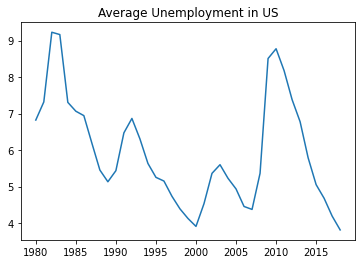

```python
dfu1.plot(kind="line", legend=False, title="Average Unemployment in US")
plt.show()
```

```python
dfl1=dfl.copy()
dfl1=dfl1.replace(to_replace="Dem",value=0) #Replace all values with integer coding,where Democrat = 0
dfl1=dfl1.replace(to_replace="*Dem",value=0)
dfl1=dfl1.replace(to_replace="Rep",value=10) #Republican = 10
dfl1=dfl1.replace(to_replace="S",value=5)    #Split = 5
dfl1=dfl1.replace(to_replace="Split",value=5)
dfl1.columns = ['State','1980','1982','1984','1986','1988','1990','1992','1994','1996','1998','2000','2002','2004','2006','2008','2010','2012','2014'] #rename columns
dfl1
```

|  | State | 1980 | 1982 | 1984 | 1986 | 1988 | 1990 | 1992 | 1994 | 1996 | 1998 | 2000 | 2002 | 2004 | 2006 | 2008 | 2010 | 2012 | 2014 |
| --- | --- | --- | --- | --- | --- | --- | --- | --- | --- | --- | --- | --- | --- | --- | --- | --- | --- | --- | --- |
| 0 | Alabama | 0 | 0 | 0 | 0 | 0 | 0 | 0 | 0 | 0 | 0 | 0 | 0 | 0 | 0 | 0 | 0 | 10 | 10 |
| 1 | Alaska | 5 | 5 | 5 | 5 | 5 | 5 | 5 | 10 | 10 | 10 | 10 | 10 | 10 | 10 | 5 | 5 | 5 | 10 |
| 2 | Arizona | 10 | 10 | 10 | 10 | 10 | 10 | 10 | 10 | 10 | 10 | 5 | 10 | 10 | 10 | 10 | 10 | 10 | 10 |
| 3 | Arkansas | 0 | 0 | 0 | 0 | 0 | 0 | 0 | 0 | 0 | 0 | 0 | 0 | 0 | 0 | 0 | 0 | 0 | 10 |
| 4 | California | 0 | 0 | 0 | 0 | 0 | 0 | 0 | 0 | 0 | 0 | 0 | 0 | 0 | 0 | 0 | 0 | 0 | 0 |
| 5 | Colorado | 10 | 10 | 10 | 10 | 10 | 10 | 10 | 10 | 10 | 10 | 5 | 10 | 0 | 0 | 0 | 0 | 5 | 0 |
| 6 | Connecticut | 0 | 0 | 0 | 0 | 0 | 0 | 0 | 0 | 0 | 0 | 0 | 0 | 0 | 0 | 0 | 0 | 0 | 0 |
| 7 | Delaware | 0 | 0 | 0 | 5 | 5 | 5 | 5 | 5 | 5 | 5 | 5 | 5 | 5 | 5 | 0 | 0 | 0 | 0 |
| 8 | Florida | 0 | 0 | 0 | 0 | 0 | 0 | 5 | 5 | 10 | 10 | 10 | 10 | 10 | 10 | 10 | 10 | 10 | 10 |
| 9 | Georgia | 0 | 0 | 0 | 0 | 0 | 0 | 0 | 0 | 0 | 0 | 0 | 5 | 10 | 10 | 10 | 10 | 10 | 10 |
| 10 | Hawaii | 0 | 0 | 0 | 0 | 0 | 0 | 0 | 0 | 0 | 0 | 0 | 0 | 0 | 0 | 0 | 0 | 0 | 0 |
| 11 | Idaho | 10 | 10 | 10 | 10 | 10 | 5 | 10 | 10 | 10 | 10 | 10 | 10 | 10 | 10 | 10 | 10 | 10 | 10 |
| 12 | Illinois | 5 | 0 | 0 | 0 | 0 | 0 | 5 | 5 | 5 | 5 | 5 | 0 | 0 | 0 | 0 | 0 | 0 | 0 |
| 13 | Indiana | 10 | 10 | 10 | 10 | 5 | 5 | 5 | 5 | 5 | 5 | 5 | 5 | 10 | 5 | 5 | 5 | 10 | 10 |
| 14 | Iowa | 10 | 0 | 0 | 0 | 0 | 0 | 0 | 5 | 10 | 10 | 10 | 10 | 5 | 0 | 0 | 0 | 5 | 5 |
| 15 | Kansas | 10 | 10 | 10 | 10 | 10 | 5 | 5 | 10 | 10 | 10 | 10 | 10 | 10 | 10 | 10 | 10 | 10 | 10 |
| 16 | Kentucky | 0 | 0 | 0 | 0 | 0 | 0 | 0 | 0 | 0 | 0 | 5 | 5 | 5 | 5 | 5 | 5 | 5 | 5 |
| 17 | Louisiana | 0 | 0 | 0 | 0 | 0 | 0 | 0 | 0 | 0 | 0 | 0 | 0 | 0 | 0 | 0 | 0 | 10 | 10 |
| 18 | Maine | 5 | 0 | 0 | 0 | 0 | 0 | 0 | 0 | 0 | 0 | 5 | 0 | 0 | 0 | 0 | 0 | 10 | 0 |
| 19 | Maryland | 0 | 0 | 0 | 0 | 0 | 0 | 0 | 0 | 0 | 0 | 0 | 0 | 0 | 0 | 0 | 0 | 0 | 0 |
| 20 | Massachusetts | 0 | 0 | 0 | 0 | 0 | 0 | 0 | 0 | 0 | 0 | 0 | 0 | 0 | 0 | 0 | 0 | 0 | 0 |
| 21 | Michigan | 0 | 0 | 5 | 5 | 5 | 5 | 5 | 5 | 5 | 10 | 10 | 10 | 10 | 5 | 5 | 5 | 10 | 10 |
| 22 | Minnesota | 5 | 0 | 5 | 5 | 0 | 0 | 0 | 0 | 0 | 5 | 5 | 5 | 5 | 0 | 0 | 0 | 10 | 0 |
| 23 | Mississippi | 0 | 0 | 0 | 0 | 0 | 0 | 0 | 0 | 0 | 0 | 0 | 0 | 0 | 0 | 0 | 0 | 10 | 10 |
| 24 | Missouri | 0 | 0 | 0 | 0 | 0 | 0 | 0 | 0 | 0 | 0 | 5 | 10 | 10 | 10 | 10 | 10 | 10 | 10 |
| 25 | Montana | 10 | 5 | 5 | 5 | 5 | 5 | 5 | 10 | 10 | 10 | 10 | 10 | 5 | 5 | 5 | 5 | 10 | 10 |
| 26 | Nevada | 0 | 0 | 5 | 5 | 5 | 5 | 5 | 5 | 5 | 5 | 5 | 5 | 5 | 5 | 0 | 0 | 0 | 0 |
| 27 | New Hampshire | 10 | 10 | 10 | 10 | 10 | 10 | 10 | 10 | 10 | 5 | 10 | 10 | 10 | 0 | 0 | 0 | 10 | 5 |
| 28 | New Jersey | 0 | 0 | 5 | 5 | 0 | 0 | 10 | 10 | 10 | 10 | 10 | 5 | 0 | 0 | 0 | 0 | 0 | 0 |
| 29 | New Mexico | 0 | 0 | 5 | 5 | 0 | 0 | 0 | 0 | 0 | 0 | 0 | 0 | 0 | 0 | 0 | 0 | 0 | 0 |
| 30 | New York | 5 | 5 | 5 | 5 | 5 | 5 | 5 | 5 | 5 | 5 | 5 | 5 | 5 | 5 | 0 | 0 | 5 | 0 |
| 31 | North Carolina | 0 | 0 | 0 | 0 | 0 | 0 | 0 | 0 | 0 | 0 | 0 | 5 | 0 | 0 | 0 | 0 | 10 | 10 |
| 32 | North Dakota | 10 | 5 | 10 | 5 | 5 | 5 | 5 | 10 | 10 | 10 | 10 | 10 | 10 | 10 | 10 | 10 | 10 | 10 |
| 33 | Ohio | 5 | 0 | 5 | 5 | 5 | 5 | 5 | 10 | 10 | 10 | 10 | 10 | 10 | 10 | 5 | 5 | 10 | 10 |
| 34 | Oklahoma | 0 | 0 | 0 | 0 | 0 | 0 | 0 | 0 | 0 | 0 | 0 | 0 | 5 | 5 | 10 | 10 | 10 | 10 |
| 35 | Oregon | 0 | 0 | 0 | 0 | 0 | 0 | 5 | 10 | 10 | 10 | 10 | 5 | 5 | 0 | 0 | 0 | 5 | 0 |
| 36 | Pennsylvania | 10 | 5 | 5 | 5 | 5 | 5 | 5 | 10 | 10 | 10 | 10 | 10 | 10 | 10 | 5 | 5 | 10 | 10 |
| 37 | Rhode Island | 0 | 0 | 0 | 0 | 0 | 0 | 0 | 0 | 0 | 0 | 0 | 0 | 0 | 0 | 0 | 0 | 0 | 0 |
| 38 | South Carolina | 0 | 0 | 0 | 0 | 0 | 0 | 0 | 5 | 5 | 5 | 5 | 10 | 10 | 10 | 10 | 10 | 10 | 10 |
| 39 | South Dakota | 10 | 10 | 10 | 10 | 10 | 10 | 5 | 10 | 10 | 10 | 10 | 10 | 10 | 10 | 10 | 10 | 10 | 10 |
| 40 | Tennessee | 0 | 0 | 0 | 0 | 0 | 0 | 0 | 0 | 0 | 0 | 0 | 0 | 5 | 5 | 10 | 10 | 10 | 10 |
| 41 | Texas | 0 | 0 | 0 | 0 | 0 | 0 | 0 | 0 | 5 | 5 | 10 | 10 | 10 | 10 | 10 | 10 | 10 | 10 |
| 42 | Utah | 10 | 10 | 10 | 10 | 10 | 10 | 10 | 10 | 10 | 10 | 10 | 10 | 10 | 10 | 10 | 10 | 10 | 10 |
| 43 | Vermont | 10 | 10 | 5 | 5 | 5 | 5 | 5 | 5 | 5 | 0 | 5 | 5 | 0 | 0 | 0 | 0 | 0 | 0 |
| 44 | Virginia | 0 | 0 | 0 | 0 | 0 | 0 | 0 | 0 | 5 | 5 | 10 | 10 | 10 | 10 | 5 | 5 | 5 | 5 |
| 45 | Washington | 10 | 0 | 0 | 0 | 5 | 5 | 0 | 5 | 5 | 5 | 5 | 5 | 0 | 0 | 0 | 0 | 0 | 0 |
| 46 | West Virginia | 0 | 0 | 0 | 0 | 0 | 0 | 0 | 0 | 0 | 0 | 0 | 0 | 0 | 0 | 0 | 0 | 0 | 0 |
| 47 | Wisconsin | 0 | 0 | 0 | 0 | 0 | 0 | 0 | 5 | 5 | 5 | 5 | 10 | 10 | 5 | 0 | 0 | 10 | 10 |
| 48 | Wyoming | 10 | 10 | 10 | 10 | 10 | 10 | 10 | 10 | 10 | 10 | 10 | 10 | 10 | 10 | 10 | 10 | 10 | 10 |

```python
dfl2=dfl1.copy()
dfl2=dfl2.iloc[:, 1:] #Eliminate State column for calculation
dfl2=dfl2.mean() #Average of previously coded dataframe. Range 0-10 where <5 is more Democrat leaning and >5 is Republican leaning
dfl2
```

```
1980    3.673469
1982    2.551020
1984    3.163265
1986    3.163265
1988    2.857143
1990    2.653061
1992    3.061224
1994    4.285714
1996    4.693878
1998    4.693878
2000    5.204082
2002    5.510204
2004    5.102041
2006    4.285714
2008    3.673469
2010    3.673469
2012    6.224490
2014    5.714286
dtype: float64
```

```python
#zip unemployment and legislative control dataframes together
year =['1980','1982','1984','1986','1988','1990','1992','1994','1996','1998','2000','2002','2004','2006','2008','2010','2012','2014']
df = pd.DataFrame(list(zip( dfl2 , dfu1)),
                  index = year,
                  columns = ['Legislative Control' , 'Unemployment' ])
df
```

|  | Legislative Control | Unemployment |
| --- | --- | --- |
| 1980 | 3.673469 | 6.823077 |
| 1982 | 2.551020 | 7.319231 |
| 1984 | 3.163265 | 9.228846 |
| 1986 | 3.163265 | 9.165385 |
| 1988 | 2.857143 | 7.307692 |
| 1990 | 2.653061 | 7.065385 |
| 1992 | 3.061224 | 6.944231 |
| 1994 | 4.285714 | 6.192308 |
| 1996 | 4.693878 | 5.453846 |
| 1998 | 4.693878 | 5.132692 |
| 2000 | 5.204082 | 5.436538 |
| 2002 | 5.510204 | 6.473077 |
| 2004 | 5.102041 | 6.867308 |
| 2006 | 4.285714 | 6.307692 |
| 2008 | 3.673469 | 5.634615 |
| 2010 | 3.673469 | 5.253846 |
| 2012 | 6.224490 | 5.151923 |
| 2014 | 5.714286 | 4.734615 |

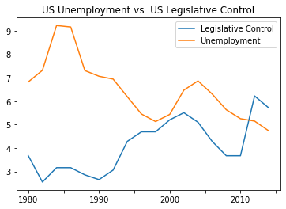

```python
df.plot(kind='line',title='US Unemployment vs. US Legislative Control')
plt.show()
```

```python
allcorr=[]
USlegis=df.corr()
allcorr.append({'US Legis': USlegis[:1]})
allcorr
#high correlation
```

```
[{'US Legis':                      Legislative Control  Unemployment
  Legislative Control                  1.0     -0.647536}]
```

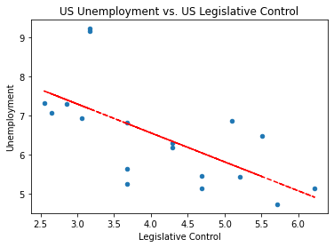

```python
df.plot(kind='scatter',x='Legislative Control',y='Unemployment',title='US Unemployment vs. US Legislative Control')
x=df['Legislative Control']
y=df['Unemployment']
z = np.polyfit(x, y, 1)
p = np.poly1d(z)
plt.plot(x,p(x),"r--")
#Conclusion: lower tax rates when Republican legilative control
```

```python
dfiowau=dfu.iloc[16] #Select only Iowa unemployment data
dfiowau=dfiowau[1:]
dfiowau=dfiowau.iloc[::2]
dfiowau
```

```
1980    6.0
1982    8.5
1984    7.0
1986    6.8
1988    4.5
1990    4.4
1992    4.5
1994    3.5
1996    3.5
1998    2.7
2000    2.6
2002    4.0
2004    4.5
2006    3.7
2008    4.2
2010    6.0
2012    5.0
2014    4.2
2016    3.6
2018    2.5
Name: 16, dtype: object
```

```python
dfiowal=dfl1.iloc[14] #Select only Iowa legislative data
dfiowal=dfiowal[1:]
dfiowal
```

```
1980    10
1982     0
1984     0
1986     0
1988     0
1990     0
1992     0
1994     5
1996    10
1998    10
2000    10
2002    10
2004     5
2006     0
2008     0
2010     0
2012     5
2014     5
Name: 14, dtype: object
```

```python
#Zip Iowa dataframes together
year =['1980','1982','1984','1986','1988','1990','1992','1994','1996','1998','2000','2002','2004','2006','2008','2010','2012','2014']
df1 = pd.DataFrame(list(zip( dfiowal , dfiowau)),
                  index = year,
                  columns = ['Legislative Control' , 'Unemployment' ])
df1
```

|  | Legislative Control | Unemployment |
| --- | --- | --- |
| 1980 | 10 | 6.0 |
| 1982 | 0 | 8.5 |
| 1984 | 0 | 7.0 |
| 1986 | 0 | 6.8 |
| 1988 | 0 | 4.5 |
| 1990 | 0 | 4.4 |
| 1992 | 0 | 4.5 |
| 1994 | 5 | 3.5 |
| 1996 | 10 | 3.5 |
| 1998 | 10 | 2.7 |
| 2000 | 10 | 2.6 |
| 2002 | 10 | 4.0 |
| 2004 | 5 | 4.5 |
| 2006 | 0 | 3.7 |
| 2008 | 0 | 4.2 |
| 2010 | 0 | 6.0 |
| 2012 | 5 | 5.0 |
| 2014 | 5 | 4.2 |

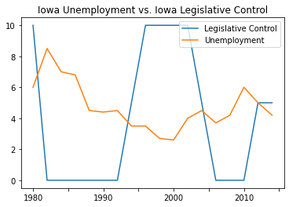

```python
df1.plot(kind='line',title='Iowa Unemployment vs. Iowa Legislative Control')
plt.show()
```

```python
Iowalegis=df1.corr()
allcorr.append({'Iowalegis': Iowalegis[:1]})
Iowalegis
allcorr
```

```
[{'US Legis':                      Legislative Control  Unemployment
  Legislative Control                  1.0     -0.647536},
 {'Iowalegis':                      Legislative Control  Unemployment
  Legislative Control                  1.0     -0.507711}]
```

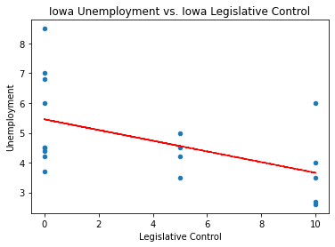

```python
df1.plot(kind='scatter',x='Legislative Control',y='Unemployment',title='Iowa Unemployment vs. Iowa Legislative Control')
x=df1['Legislative Control']
y=df1['Unemployment']
z = np.polyfit(x, y, 1)
p = np.poly1d(z)
plt.plot(x,p(x),"r--")
#Conclusion:inconclusive, but still trending that Republican control has lower tax rates
```

### Compare Unemployment to House, Senate, and Presidential Party

```python
dfg.iloc[[18,19],[2,4]]="Divided" #Clean the data for better graphs
dfg.iloc[[12,13],2]="Democrats"

dfg1=dfg.sort_values(by=['Congress'])
dfg1['Year'] = dfg1['Congress']    #Change index values to year
dfg1=dfg1.set_index('Year')
dfg1=dfg1[:-2]
dfg1
```

| Year | Congress | House Majority | Senate Majority | Presidency | Party Government |
| --- | --- | --- | --- | --- | --- |
| 1980 | 1980 | Democrats | Democrats | Democrat | Unified |
| 1981 | 1981 | Democrats | Republicans | Republican | Divided |
| 1982 | 1982 | Democrats | Republicans | Republican | Divided |
| 1983 | 1983 | Democrats | Republicans | Republican | Divided |
| 1984 | 1984 | Democrats | Republicans | Republican | Divided |
| 1985 | 1985 | Democrats | Republicans | Republican | Divided |
| 1986 | 1986 | Democrats | Republicans | Republican | Divided |
| 1987 | 1987 | Democrats | Democrats | Republican | Divided |
| 1988 | 1988 | Democrats | Democrats | Republican | Divided |
| 1989 | 1989 | Democrats | Democrats | Republican | Divided |
| 1990 | 1990 | Democrats | Democrats | Republican | Divided |
| 1991 | 1991 | Democrats | Democrats | Republican | Divided |
| 1992 | 1992 | Democrats | Democrats | Republican | Divided |
| 1993 | 1993 | Democrats | Democrats | Democrat | Unified |
| 1994 | 1994 | Democrats | Democrats | Democrat | Unified |
| 1995 | 1995 | Republicans | Republicans | Democrat | Divided |
| 1996 | 1996 | Republicans | Republicans | Democrat | Divided |
| 1997 | 1997 | Republicans | Republicans | Democrat | Divided |
| 1998 | 1998 | Republicans | Republicans | Democrat | Divided |
| 1999 | 1999 | Republicans | Republicans | Democrat | Divided |
| 2000 | 2000 | Republicans | Republicans | Democrat | Divided |
| 2001 | 2001 | Republicans | Divided | Republican | Divided |
| 2002 | 2002 | Republicans | Divided | Republican | Divided |
| 2003 | 2003 | Republicans | Republicans | Republican | Unified |
| 2004 | 2004 | Republicans | Republicans | Republican | Unified |
| 2005 | 2005 | Republicans | Republicans | Republican | Unified |
| 2006 | 2006 | Republicans | Republicans | Republican | Unified |
| 2007 | 2007 | Democrats | Democrats | Republican | Divided |
| 2008 | 2008 | Democrats | Democrats | Republican | Divided |
| 2009 | 2009 | Democrats | Democrats | Democrat | Unified |
| 2010 | 2010 | Democrats | Democrats | Democrat | Unified |
| 2011 | 2011 | Republicans | Democrats | Democrat | Divided |
| 2012 | 2012 | Republicans | Democrats | Democrat | Divided |
| 2013 | 2013 | Republicans | Democrats | Democrat | Divided |
| 2014 | 2014 | Republicans | Democrats | Democrat | Divided |
| 2015 | 2015 | Republicans | Republicans | Democrat | Divided |
| 2016 | 2016 | Republicans | Republicans | Democrat | Divided |
| 2017 | 2017 | Republicans | Republicans | Republican | Unified |
| 2018 | 2018 | Republicans | Republicans | Republican | Unified |

```python
#Zip unemployment and congress dataframes together
year = dfg1.index
df2 = pd.DataFrame(list(zip( dfg1.Congress ,dfg1.Presidency, dfu1)),
                  index = year,
                  columns = ['Year','President Party' , 'Unemployment' ])
df2
```

| Year | Year | President Party | Unemployment |
| --- | --- | --- | --- |
| 1980 | 1980 | Democrat | 6.823077 |
| 1981 | 1981 | Republican | 7.319231 |
| 1982 | 1982 | Republican | 9.228846 |
| 1983 | 1983 | Republican | 9.165385 |
| 1984 | 1984 | Republican | 7.307692 |
| 1985 | 1985 | Republican | 7.065385 |
| 1986 | 1986 | Republican | 6.944231 |
| 1987 | 1987 | Republican | 6.192308 |
| 1988 | 1988 | Republican | 5.453846 |
| 1989 | 1989 | Republican | 5.132692 |
| 1990 | 1990 | Republican | 5.436538 |
| 1991 | 1991 | Republican | 6.473077 |
| 1992 | 1992 | Republican | 6.867308 |
| 1993 | 1993 | Democrat | 6.307692 |
| 1994 | 1994 | Democrat | 5.634615 |
| 1995 | 1995 | Democrat | 5.253846 |
| 1996 | 1996 | Democrat | 5.151923 |
| 1997 | 1997 | Democrat | 4.734615 |
| 1998 | 1998 | Democrat | 4.390385 |
| 1999 | 1999 | Democrat | 4.126923 |
| 2000 | 2000 | Democrat | 3.909615 |
| 2001 | 2001 | Republican | 4.532692 |
| 2002 | 2002 | Republican | 5.363462 |
| 2003 | 2003 | Republican | 5.600000 |
| 2004 | 2004 | Republican | 5.226923 |
| 2005 | 2005 | Republican | 4.936538 |
| 2006 | 2006 | Republican | 4.455769 |
| 2007 | 2007 | Republican | 4.375000 |
| 2008 | 2008 | Republican | 5.365385 |
| 2009 | 2009 | Democrat | 8.509615 |
| 2010 | 2010 | Democrat | 8.776923 |
| 2011 | 2011 | Democrat | 8.176923 |
| 2012 | 2012 | Democrat | 7.382692 |
| 2013 | 2013 | Democrat | 6.776923 |
| 2014 | 2014 | Democrat | 5.790385 |
| 2015 | 2015 | Democrat | 5.053846 |
| 2016 | 2016 | Democrat | 4.678846 |
| 2017 | 2017 | Republican | 4.192308 |
| 2018 | 2018 | Republican | 3.813462 |

```python
year = dfg1.index
df3 = pd.DataFrame(list(zip( dfg1.Congress ,dfg1['Senate Majority'], dfu1)),
                  index = year,
                  columns = ['Year','Senate Majority' , 'Unemployment' ])
```

```python
year = dfg1.index
df4 = pd.DataFrame(list(zip( dfg1.Congress ,dfg1['House Majority'], dfu1)),
                  index = year,
                  columns = ['Year','House Majority' , 'Unemployment' ])
```

```python
year = dfg1.index
df5 = pd.DataFrame(list(zip( dfg1.Congress ,dfg1['Party Government'], dfu1)),
                  index = year,
                  columns = ['Year','Party' , 'Unemployment' ])
```

```python
from ipywidgets import widgets, interactive, Layout

w_gov= widgets.RadioButtons(
    options=['President', 'Senate', 'House','All'],
    value='President',
    description='Government:',
    disabled= False)

def view(government):
    if government == 'President':
        fg = seaborn.FacetGrid(data=df2, hue='President Party', aspect=2)
        fg.map(plt.scatter,'Year', 'Unemployment').add_legend()

    elif government == 'Senate':
        fg = seaborn.FacetGrid(data=df3, hue='Senate Majority', aspect=2)
        fg.map(plt.scatter,'Year', 'Unemployment').add_legend()

    elif government == 'House':
        fg = seaborn.FacetGrid(data=df4, hue='House Majority', aspect=2)
        fg.map(plt.scatter,'Year', 'Unemployment').add_legend()

    else:
        fg = seaborn.FacetGrid(data=df5, hue='Party', aspect=2)
        fg.map(plt.scatter,'Year', 'Unemployment').add_legend()


i = interactive(view, government=w_gov)
display(i)
```

##### On the national level, Democrat control of Presidency and Senate generally result in lower unemployment, but control of House results in higher unemplyoyment. Compared to Iowa, this is opposite of what we might expect

### Comparing Iowa's governing body to national governing bodies

Is Iowa’s unemployment rate significantly higher when the party with a history of higher unemployment rates has control over both Iowa’s governing bodies and national governing bodies?

```python
Iowa=df1
Iowa.columns=['Iowalegis','Unemployment']
Iowa
```

|  | Iowalegis | Unemployment |
| --- | --- | --- |
| 1980 | 10 | 6.0 |
| 1982 | 0 | 8.5 |
| 1984 | 0 | 7.0 |
| 1986 | 0 | 6.8 |
| 1988 | 0 | 4.5 |
| 1990 | 0 | 4.4 |
| 1992 | 0 | 4.5 |
| 1994 | 5 | 3.5 |
| 1996 | 10 | 3.5 |
| 1998 | 10 | 2.7 |
| 2000 | 10 | 2.6 |
| 2002 | 10 | 4.0 |
| 2004 | 5 | 4.5 |
| 2006 | 0 | 3.7 |
| 2008 | 0 | 4.2 |
| 2010 | 0 | 6.0 |
| 2012 | 5 | 5.0 |
| 2014 | 5 | 4.2 |

```python
nat=dfg1[['Congress','Presidency','Party Government']]
nat['Party']=nat['Party Government']
nat=nat.loc[::2]
nat
```

| Year | Congress | Presidency | Party Government | Party |
| --- | --- | --- | --- | --- |
| 1980 | 1980 | Democrat | Unified | Unified |
| 1982 | 1982 | Republican | Divided | Divided |
| 1984 | 1984 | Republican | Divided | Divided |
| 1986 | 1986 | Republican | Divided | Divided |
| 1988 | 1988 | Republican | Divided | Divided |
| 1990 | 1990 | Republican | Divided | Divided |
| 1992 | 1992 | Republican | Divided | Divided |
| 1994 | 1994 | Democrat | Unified | Unified |
| 1996 | 1996 | Democrat | Divided | Divided |
| 1998 | 1998 | Democrat | Divided | Divided |
| 2000 | 2000 | Democrat | Divided | Divided |
| 2002 | 2002 | Republican | Divided | Divided |
| 2004 | 2004 | Republican | Unified | Unified |
| 2006 | 2006 | Republican | Unified | Unified |
| 2008 | 2008 | Republican | Divided | Divided |
| 2010 | 2010 | Democrat | Unified | Unified |
| 2012 | 2012 | Democrat | Divided | Divided |
| 2014 | 2014 | Democrat | Divided | Divided |
| 2016 | 2016 | Democrat | Divided | Divided |
| 2018 | 2018 | Republican | Unified | Unified |

```python
year =Iowa.index
div = pd.DataFrame(list(zip(nat.Congress,Iowa.Iowalegis , Iowa.Unemployment, nat.Presidency, nat.Party)),
                  index = year,
                  columns = ['Year','Iowa', 'Unemployment','Presidency','Divided'])
div
```

|  | Year | Iowa | Unemployment | Presidency | Divided |
| --- | --- | --- | --- | --- | --- |
| 1980 | 1980 | 10 | 6.0 | Democrat | Unified |
| 1982 | 1982 | 0 | 8.5 | Republican | Divided |
| 1984 | 1984 | 0 | 7.0 | Republican | Divided |
| 1986 | 1986 | 0 | 6.8 | Republican | Divided |
| 1988 | 1988 | 0 | 4.5 | Republican | Divided |
| 1990 | 1990 | 0 | 4.4 | Republican | Divided |
| 1992 | 1992 | 0 | 4.5 | Republican | Divided |
| 1994 | 1994 | 5 | 3.5 | Democrat | Unified |
| 1996 | 1996 | 10 | 3.5 | Democrat | Divided |
| 1998 | 1998 | 10 | 2.7 | Democrat | Divided |
| 2000 | 2000 | 10 | 2.6 | Democrat | Divided |
| 2002 | 2002 | 10 | 4.0 | Republican | Divided |
| 2004 | 2004 | 5 | 4.5 | Republican | Unified |
| 2006 | 2006 | 0 | 3.7 | Republican | Unified |
| 2008 | 2008 | 0 | 4.2 | Republican | Divided |
| 2010 | 2010 | 0 | 6.0 | Democrat | Unified |
| 2012 | 2012 | 5 | 5.0 | Democrat | Divided |
| 2014 | 2014 | 5 | 4.2 | Democrat | Divided |

```python
div['Compare'] = div.apply(lambda x : 'Unified' if x['Iowa'] == 10 and x['Presidency'] == 'Republican' or x['Iowa'] == 0 and x['Presidency'] == 'Democrat' else "Divided", axis=1)
div
```

|  | Year | Iowa | Unemployment | Presidency | Divided | Compare |
| --- | --- | --- | --- | --- | --- | --- |
| 1980 | 1980 | 10 | 6.0 | Democrat | Unified | Divided |
| 1982 | 1982 | 0 | 8.5 | Republican | Divided | Divided |
| 1984 | 1984 | 0 | 7.0 | Republican | Divided | Divided |
| 1986 | 1986 | 0 | 6.8 | Republican | Divided | Divided |
| 1988 | 1988 | 0 | 4.5 | Republican | Divided | Divided |
| 1990 | 1990 | 0 | 4.4 | Republican | Divided | Divided |
| 1992 | 1992 | 0 | 4.5 | Republican | Divided | Divided |
| 1994 | 1994 | 5 | 3.5 | Democrat | Unified | Divided |
| 1996 | 1996 | 10 | 3.5 | Democrat | Divided | Divided |
| 1998 | 1998 | 10 | 2.7 | Democrat | Divided | Divided |
| 2000 | 2000 | 10 | 2.6 | Democrat | Divided | Divided |
| 2002 | 2002 | 10 | 4.0 | Republican | Divided | Unified |
| 2004 | 2004 | 5 | 4.5 | Republican | Unified | Divided |
| 2006 | 2006 | 0 | 3.7 | Republican | Unified | Divided |
| 2008 | 2008 | 0 | 4.2 | Republican | Divided | Divided |
| 2010 | 2010 | 0 | 6.0 | Democrat | Unified | Unified |
| 2012 | 2012 | 5 | 5.0 | Democrat | Divided | Divided |
| 2014 | 2014 | 5 | 4.2 | Democrat | Divided | Divided |

```python
div['Control'] = div.apply(lambda x : 'Unified' if x['Divided'] == 'Unified' and x['Compare'] == 'Unified' else "Divided", axis=1)
div
```

|  | Year | Iowa | Unemployment | Presidency | Divided | Compare | Control |
| --- | --- | --- | --- | --- | --- | --- | --- |
| 1980 | 1980 | 10 | 6.0 | Democrat | Unified | Divided | Divided |
| 1982 | 1982 | 0 | 8.5 | Republican | Divided | Divided | Divided |
| 1984 | 1984 | 0 | 7.0 | Republican | Divided | Divided | Divided |
| 1986 | 1986 | 0 | 6.8 | Republican | Divided | Divided | Divided |
| 1988 | 1988 | 0 | 4.5 | Republican | Divided | Divided | Divided |
| 1990 | 1990 | 0 | 4.4 | Republican | Divided | Divided | Divided |
| 1992 | 1992 | 0 | 4.5 | Republican | Divided | Divided | Divided |
| 1994 | 1994 | 5 | 3.5 | Democrat | Unified | Divided | Divided |
| 1996 | 1996 | 10 | 3.5 | Democrat | Divided | Divided | Divided |
| 1998 | 1998 | 10 | 2.7 | Democrat | Divided | Divided | Divided |
| 2000 | 2000 | 10 | 2.6 | Democrat | Divided | Divided | Divided |
| 2002 | 2002 | 10 | 4.0 | Republican | Divided | Unified | Divided |
| 2004 | 2004 | 5 | 4.5 | Republican | Unified | Divided | Divided |
| 2006 | 2006 | 0 | 3.7 | Republican | Unified | Divided | Divided |
| 2008 | 2008 | 0 | 4.2 | Republican | Divided | Divided | Divided |
| 2010 | 2010 | 0 | 6.0 | Democrat | Unified | Unified | Unified |
| 2012 | 2012 | 5 | 5.0 | Democrat | Divided | Divided | Divided |
| 2014 | 2014 | 5 | 4.2 | Democrat | Divided | Divided | Divided |

```python
div=div[['Year','Control','Unemployment']]
```

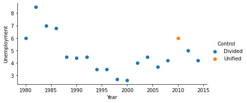

```python
fg = seaborn.FacetGrid(data=div, hue='Control', aspect=2)
fg.map(plt.scatter,'Year', 'Unemployment').add_legend()
#Conclusion: nonconclusive, does not provide any insight
```

# Inflation Analysis

### Editing dataframes for analysis:

#### Reading unemployment data file:

```python
dfu=pd.read_csv("files/stateunemp.csv")
dfu
```

|  | Area | 1980 | 1981 | 1982 | 1983 | 1984 | 1985 | 1986 | 1987 | 1988 | ... | 2009 | 2010 | 2011 | 2012 | 2013 | 2014 | 2015 | 2016 | 2017 | 2018 |
| --- | --- | --- | --- | --- | --- | --- | --- | --- | --- | --- | --- | --- | --- | --- | --- | --- | --- | --- | --- | --- | --- |
| 0 | United States | 7.1 | 7.6 | 9.7 | 9.6 | 7.5 | 7.2 | 7.0 | 6.2 | 5.5 | ... | 9.3 | 9.6 | 8.9 | 8.1 | 7.4 | 6.2 | 5.3 | 4.9 | 4.4 | 3.9 |
| 1 | Alabama | 8.9 | 10.6 | 14.1 | 13.8 | 11.0 | 9.2 | 9.7 | 8.1 | 7.2 | ... | 11.0 | 10.5 | 9.6 | 8.0 | 7.2 | 6.8 | 6.1 | 5.8 | 4.4 | 3.9 |
| 2 | Alaska | 9.6 | 9.4 | 9.9 | 9.9 | 9.8 | 9.7 | 10.9 | 10.3 | 8.8 | ... | 7.7 | 7.9 | 7.6 | 7.1 | 7.0 | 6.9 | 6.5 | 6.9 | 7.0 | 6.6 |
| 3 | Arizona | 6.6 | 6.2 | 10.1 | 8.8 | 5.2 | 6.3 | 6.9 | 6.5 | 6.4 | ... | 9.9 | 10.4 | 9.5 | 8.3 | 7.7 | 6.8 | 6.1 | 5.4 | 4.9 | 4.8 |
| 4 | Arkansas | 7.6 | 8.7 | 9.9 | 9.9 | 8.7 | 8.7 | 8.6 | 8.1 | 7.6 | ... | 7.8 | 8.2 | 8.3 | 7.6 | 7.2 | 6.0 | 5.0 | 4.0 | 3.7 | 3.7 |
| 5 | California | 6.8 | 7.4 | 10.0 | 9.8 | 7.8 | 7.2 | 6.7 | 5.8 | 5.3 | ... | 11.2 | 12.2 | 11.7 | 10.4 | 8.9 | 7.5 | 6.2 | 5.5 | 4.8 | 4.2 |
| 6 | Colorado | 5.8 | 5.7 | 7.3 | 7.1 | 5.4 | 6.1 | 7.5 | 7.5 | 6.5 | ... | 7.3 | 8.7 | 8.4 | 7.9 | 6.9 | 5.0 | 3.9 | 3.2 | 2.7 | 3.3 |
| 7 | Connecticut | 5.8 | 6.2 | 6.9 | 6.0 | 4.7 | 4.7 | 3.8 | 3.4 | 3.0 | ... | 7.9 | 9.1 | 8.8 | 8.3 | 7.8 | 6.6 | 5.7 | 5.1 | 4.7 | 4.1 |
| 8 | Delaware | 7.6 | 7.8 | 8.4 | 7.7 | 6.3 | 5.1 | 4.3 | 3.1 | 3.1 | ... | 8.3 | 8.4 | 7.5 | 7.2 | 6.7 | 5.7 | 4.9 | 4.5 | 4.5 | 3.8 |
| 9 | District of Columbia | 7.4 | 8.9 | 10.4 | 11.2 | 9.1 | 8.1 | 7.5 | 6.3 | 5.0 | ... | 9.3 | 9.4 | 10.2 | 9.0 | 8.5 | 7.8 | 6.9 | 6.1 | 6.1 | 5.6 |
| 10 | Florida | 6.1 | 6.7 | 8.4 | 8.5 | 6.4 | 6.0 | 5.8 | 5.3 | 5.1 | ... | 10.4 | 11.1 | 10.0 | 8.5 | 7.2 | 6.3 | 5.5 | 4.8 | 4.2 | 3.6 |
| 11 | Georgia | 6.3 | 6.4 | 7.8 | 7.7 | 6.1 | 6.4 | 6.0 | 5.7 | 5.7 | ... | 9.9 | 10.5 | 10.2 | 9.2 | 8.2 | 7.1 | 6.0 | 5.4 | 4.7 | 3.9 |
| 12 | Hawaii | 5.0 | 5.4 | 6.3 | 6.2 | 5.7 | 5.4 | 4.8 | 3.8 | 3.2 | ... | 7.2 | 6.9 | 6.8 | 6.0 | 4.9 | 4.4 | 3.6 | 3.0 | 2.4 | 2.4 |
| 13 | Idaho | 7.5 | 7.7 | 9.9 | 8.9 | 7.3 | 7.9 | 8.4 | 7.6 | 6.0 | ... | 8.8 | 9.0 | 8.3 | 7.2 | 6.1 | 4.8 | 4.2 | 3.8 | 3.2 | 2.8 |
| 14 | Illinois | 8.2 | 8.5 | 11.4 | 11.8 | 9.0 | 9.1 | 8.3 | 7.4 | 6.7 | ... | 10.2 | 10.4 | 9.7 | 9.0 | 9.0 | 7.1 | 6.0 | 5.8 | 4.9 | 4.3 |
| 15 | Indiana | 9.6 | 9.9 | 12.0 | 11.2 | 8.6 | 7.8 | 6.9 | 6.2 | 5.2 | ... | 10.3 | 10.4 | 9.1 | 8.3 | 7.7 | 6.0 | 4.8 | 4.4 | 3.6 | 3.4 |
| 16 | Iowa | 6.0 | 6.6 | 8.5 | 8.1 | 7.0 | 7.5 | 6.8 | 5.5 | 4.5 | ... | 6.4 | 6.0 | 5.5 | 5.0 | 4.7 | 4.2 | 3.8 | 3.6 | 3.1 | 2.5 |
| 17 | Kansas | 4.4 | 4.3 | 6.3 | 5.9 | 4.9 | 5.1 | 5.3 | 4.8 | 4.5 | ... | 6.9 | 7.1 | 6.5 | 5.7 | 5.3 | 4.5 | 4.2 | 4.0 | 3.7 | 3.4 |
| 18 | Kentucky | 8.0 | 8.6 | 10.8 | 11.4 | 9.3 | 9.2 | 9.4 | 8.5 | 7.6 | ... | 10.3 | 10.2 | 9.4 | 8.2 | 8.0 | 6.5 | 5.3 | 5.1 | 4.9 | 4.3 |
| 19 | Louisiana | 6.9 | 8.4 | 10.3 | 11.5 | 10.1 | 11.6 | 12.8 | 12.1 | 10.8 | ... | 6.8 | 8.0 | 7.8 | 7.1 | 6.7 | 6.4 | 6.3 | 6.1 | 5.1 | 4.9 |
| 20 | Maine | 7.6 | 7.4 | 8.4 | 8.3 | 6.2 | 5.5 | 5.3 | 4.4 | 3.6 | ... | 8.1 | 8.1 | 7.9 | 7.5 | 6.6 | 5.6 | 4.4 | 3.8 | 3.4 | 3.4 |
| 21 | Maryland | 6.6 | 7.3 | 8.3 | 7.0 | 5.4 | 4.6 | 4.6 | 4.4 | 4.3 | ... | 7.0 | 7.7 | 7.2 | 7.0 | 6.6 | 5.8 | 5.1 | 4.5 | 4.3 | 3.9 |
| 22 | Massachusetts | 5.6 | 6.5 | 7.7 | 6.8 | 4.8 | 4.0 | 3.9 | 3.2 | 3.3 | ... | 8.1 | 8.3 | 7.3 | 6.7 | 6.7 | 5.7 | 4.8 | 3.9 | 3.8 | 3.3 |
| 23 | Michigan | 12.3 | 12.4 | 15.4 | 14.4 | 11.2 | 10.0 | 8.8 | 8.3 | 7.5 | ... | 13.7 | 12.6 | 10.4 | 9.1 | 8.8 | 7.2 | 5.4 | 5.0 | 4.6 | 4.1 |
| 24 | Minnesota | 5.8 | 5.8 | 7.9 | 8.0 | 6.3 | 6.0 | 5.5 | 5.1 | 4.3 | ... | 7.8 | 7.4 | 6.5 | 5.6 | 5.0 | 4.2 | 3.7 | 3.9 | 3.4 | 2.9 |
| 25 | Mississippi | 7.4 | 8.5 | 11.1 | 12.1 | 10.5 | 10.4 | 11.4 | 10.0 | 8.4 | ... | 9.5 | 10.4 | 10.0 | 9.0 | 8.5 | 7.5 | 6.4 | 5.8 | 5.1 | 4.8 |
| 26 | Missouri | 7.2 | 7.6 | 9.2 | 9.9 | 7.2 | 6.5 | 6.2 | 6.3 | 5.7 | ... | 9.3 | 9.6 | 8.5 | 6.9 | 6.7 | 6.1 | 5.0 | 4.6 | 3.8 | 3.2 |
| 27 | Montana | 6.1 | 6.8 | 8.5 | 8.6 | 7.6 | 7.7 | 7.9 | 7.4 | 6.6 | ... | 6.8 | 7.3 | 6.9 | 6.0 | 5.4 | 4.7 | 4.2 | 4.1 | 3.9 | 3.7 |
| 28 | Nebraska | 3.9 | 4.2 | 5.6 | 5.6 | 4.5 | 5.2 | 5.0 | 4.4 | 3.6 | ... | 4.6 | 4.6 | 4.4 | 4.0 | 3.8 | 3.3 | 3.0 | 3.1 | 2.9 | 2.8 |
| 29 | Nevada | 6.2 | 7.2 | 9.9 | 9.6 | 7.9 | 7.7 | 6.2 | 6.1 | 5.2 | ... | 11.3 | 13.5 | 13.0 | 11.2 | 9.6 | 7.9 | 6.8 | 5.7 | 5.1 | 4.6 |
| 30 | New Hampshire | 4.5 | 5.2 | 6.8 | 5.5 | 4.3 | 3.7 | 2.8 | 2.3 | 2.4 | ... | 6.2 | 5.8 | 5.4 | 5.5 | 5.1 | 4.3 | 3.4 | 2.9 | 2.7 | 2.5 |
| 31 | New Jersey | 7.2 | 7.4 | 8.7 | 8.0 | 6.2 | 5.6 | 5.0 | 4.1 | 3.8 | ... | 9.1 | 9.5 | 9.3 | 9.3 | 8.2 | 6.8 | 5.8 | 5.0 | 4.6 | 4.1 |
| 32 | New Mexico | 7.6 | 7.3 | 9.2 | 9.7 | 7.8 | 8.3 | 9.3 | 8.7 | 7.5 | ... | 7.5 | 8.1 | 7.5 | 7.1 | 6.9 | 6.7 | 6.5 | 6.6 | 5.9 | 4.9 |
| 33 | New York | 7.5 | 7.6 | 8.5 | 8.7 | 7.2 | 6.6 | 6.2 | 4.9 | 4.3 | ... | 8.3 | 8.6 | 8.3 | 8.5 | 7.7 | 6.3 | 5.3 | 4.9 | 4.7 | 4.1 |
| 34 | North Carolina | 6.4 | 6.5 | 9.2 | 9.0 | 6.7 | 5.6 | 5.3 | 4.5 | 3.6 | ... | 10.6 | 10.9 | 10.3 | 9.3 | 8.0 | 6.3 | 5.7 | 5.1 | 4.5 | 3.9 |
| 35 | North Dakota | 4.9 | 4.8 | 5.6 | 5.7 | 5.3 | 5.7 | 5.9 | 5.0 | 4.7 | ... | 4.1 | 3.8 | 3.5 | 3.1 | 2.9 | 2.7 | 2.8 | 3.1 | 2.7 | 2.6 |
| 36 | Ohio | 8.4 | 9.4 | 12.7 | 12.4 | 9.5 | 8.9 | 8.3 | 7.1 | 6.0 | ... | 10.3 | 10.3 | 8.8 | 7.4 | 7.5 | 5.8 | 4.9 | 5.0 | 5.0 | 4.6 |
| 37 | Oklahoma | 4.4 | 3.6 | 6.0 | 8.4 | 7.1 | 7.2 | 8.2 | 7.3 | 6.4 | ... | 6.4 | 6.8 | 5.9 | 5.2 | 5.3 | 4.5 | 4.4 | 4.8 | 4.2 | 3.4 |
| 38 | Oregon | 8.5 | 9.8 | 11.5 | 10.8 | 9.4 | 8.8 | 8.0 | 6.3 | 5.8 | ... | 11.3 | 10.6 | 9.5 | 8.8 | 7.9 | 6.8 | 5.6 | 4.8 | 4.1 | 4.2 |
| 39 | Pennsylvania | 8.0 | 8.4 | 11.2 | 11.5 | 9.1 | 8.0 | 6.9 | 5.6 | 5.0 | ... | 8.0 | 8.5 | 7.9 | 7.8 | 7.4 | 5.9 | 5.3 | 5.4 | 4.9 | 4.3 |
| 40 | Rhode Island | 7.2 | 7.8 | 9.7 | 8.3 | 5.5 | 4.6 | 4.1 | 3.6 | 3.1 | ... | 11.0 | 11.2 | 11.0 | 10.4 | 9.3 | 7.7 | 6.0 | 5.2 | 4.4 | 4.1 |
| 41 | South Carolina | 6.7 | 8.1 | 11.1 | 9.9 | 6.9 | 6.9 | 6.4 | 5.5 | 4.7 | ... | 11.2 | 11.2 | 10.6 | 9.2 | 7.6 | 6.5 | 6.0 | 5.0 | 4.3 | 3.4 |
| 42 | South Dakota | 4.8 | 5.0 | 5.5 | 5.2 | 4.4 | 4.8 | 4.6 | 4.2 | 4.1 | ... | 4.9 | 5.0 | 4.7 | 4.3 | 3.8 | 3.4 | 3.1 | 3.0 | 3.2 | 3.0 |
| 43 | Tennessee | 7.4 | 9.0 | 11.7 | 11.5 | 8.5 | 7.9 | 7.9 | 6.6 | 5.8 | ... | 10.5 | 9.7 | 9.0 | 7.8 | 7.8 | 6.6 | 5.6 | 4.7 | 3.8 | 3.5 |
| 44 | Texas | 5.1 | 5.3 | 6.9 | 7.9 | 6.1 | 7.0 | 8.8 | 8.4 | 7.3 | ... | 7.6 | 8.1 | 7.8 | 6.7 | 6.3 | 5.1 | 4.4 | 4.6 | 4.3 | 3.9 |
| 45 | Utah | 6.2 | 6.6 | 8.2 | 8.7 | 6.5 | 6.0 | 6.1 | 6.2 | 5.0 | ... | 7.3 | 7.8 | 6.7 | 5.4 | 4.6 | 3.8 | 3.6 | 3.4 | 3.3 | 3.1 |
| 46 | Vermont | 6.2 | 5.8 | 7.0 | 6.4 | 5.1 | 4.8 | 4.3 | 3.6 | 3.0 | ... | 6.6 | 6.1 | 5.5 | 5.0 | 4.4 | 3.9 | 3.6 | 3.2 | 3.0 | 2.7 |
| 47 | Virginia | 5.2 | 6.0 | 7.4 | 6.4 | 5.1 | 5.5 | 5.0 | 4.3 | 3.9 | ... | 6.7 | 7.1 | 6.6 | 6.1 | 5.7 | 5.2 | 4.5 | 4.1 | 3.7 | 3.0 |
| 48 | Washington | 8.1 | 9.6 | 11.9 | 11.1 | 9.3 | 8.4 | 8.1 | 7.3 | 6.3 | ... | 9.2 | 10.0 | 9.3 | 8.1 | 7.0 | 6.1 | 5.6 | 5.3 | 4.7 | 4.5 |
| 49 | West Virginia | 9.5 | 10.6 | 14.0 | 17.8 | 14.8 | 13.1 | 11.8 | 10.8 | 9.8 | ... | 7.7 | 8.7 | 8.1 | 7.5 | 6.8 | 6.6 | 6.7 | 6.1 | 5.2 | 5.3 |
| 50 | Wisconsin | 7.2 | 8.0 | 10.5 | 10.2 | 7.4 | 7.2 | 7.0 | 5.9 | 4.4 | ... | 8.6 | 8.7 | 7.8 | 7.0 | 6.7 | 5.4 | 4.6 | 4.0 | 3.3 | 3.0 |
| 51 | Wyoming | 3.9 | 4.1 | 6.2 | 8.2 | 6.3 | 6.9 | 8.9 | 8.0 | 6.5 | ... | 6.3 | 6.4 | 5.8 | 5.3 | 4.7 | 4.1 | 4.3 | 5.3 | 4.2 | 4.1 |

52 rows × 40 columns

#### Transposing unemployment dataframe to set the year as the index and areas as the columns:

```python
dfu1 = dfu.set_index('Area').transpose()
dfu1
```

| Area | United States | Alabama | Alaska | Arizona | Arkansas | California | Colorado | Connecticut | Delaware | District of Columbia | ... | South Dakota | Tennessee | Texas | Utah | Vermont | Virginia | Washington | West Virginia | Wisconsin | Wyoming |
| --- | --- | --- | --- | --- | --- | --- | --- | --- | --- | --- | --- | --- | --- | --- | --- | --- | --- | --- | --- | --- | --- |
| 1980 | 7.1 | 8.9 | 9.6 | 6.6 | 7.6 | 6.8 | 5.8 | 5.8 | 7.6 | 7.4 | ... | 4.8 | 7.4 | 5.1 | 6.2 | 6.2 | 5.2 | 8.1 | 9.5 | 7.2 | 3.9 |
| 1981 | 7.6 | 10.6 | 9.4 | 6.2 | 8.7 | 7.4 | 5.7 | 6.2 | 7.8 | 8.9 | ... | 5.0 | 9.0 | 5.3 | 6.6 | 5.8 | 6.0 | 9.6 | 10.6 | 8.0 | 4.1 |
| 1982 | 9.7 | 14.1 | 9.9 | 10.1 | 9.9 | 10.0 | 7.3 | 6.9 | 8.4 | 10.4 | ... | 5.5 | 11.7 | 6.9 | 8.2 | 7.0 | 7.4 | 11.9 | 14.0 | 10.5 | 6.2 |
| 1983 | 9.6 | 13.8 | 9.9 | 8.8 | 9.9 | 9.8 | 7.1 | 6.0 | 7.7 | 11.2 | ... | 5.2 | 11.5 | 7.9 | 8.7 | 6.4 | 6.4 | 11.1 | 17.8 | 10.2 | 8.2 |
| 1984 | 7.5 | 11.0 | 9.8 | 5.2 | 8.7 | 7.8 | 5.4 | 4.7 | 6.3 | 9.1 | ... | 4.4 | 8.5 | 6.1 | 6.5 | 5.1 | 5.1 | 9.3 | 14.8 | 7.4 | 6.3 |
| 1985 | 7.2 | 9.2 | 9.7 | 6.3 | 8.7 | 7.2 | 6.1 | 4.7 | 5.1 | 8.1 | ... | 4.8 | 7.9 | 7.0 | 6.0 | 4.8 | 5.5 | 8.4 | 13.1 | 7.2 | 6.9 |
| 1986 | 7.0 | 9.7 | 10.9 | 6.9 | 8.6 | 6.7 | 7.5 | 3.8 | 4.3 | 7.5 | ... | 4.6 | 7.9 | 8.8 | 6.1 | 4.3 | 5.0 | 8.1 | 11.8 | 7.0 | 8.9 |
| 1987 | 6.2 | 8.1 | 10.3 | 6.5 | 8.1 | 5.8 | 7.5 | 3.4 | 3.1 | 6.3 | ... | 4.2 | 6.6 | 8.4 | 6.2 | 3.6 | 4.3 | 7.3 | 10.8 | 5.9 | 8.0 |
| 1988 | 5.5 | 7.2 | 8.8 | 6.4 | 7.6 | 5.3 | 6.5 | 3.0 | 3.1 | 5.0 | ... | 4.1 | 5.8 | 7.3 | 5.0 | 3.0 | 3.9 | 6.3 | 9.8 | 4.4 | 6.5 |
| 1989 | 5.3 | 7.0 | 7.0 | 5.3 | 7.0 | 5.1 | 5.7 | 3.8 | 3.5 | 4.9 | ... | 4.0 | 5.1 | 6.7 | 4.5 | 3.5 | 3.9 | 5.9 | 8.6 | 4.3 | 6.1 |
| 1990 | 5.6 | 6.8 | 7.2 | 5.3 | 6.9 | 5.8 | 5.2 | 5.1 | 4.7 | 6.3 | ... | 3.8 | 5.3 | 6.3 | 4.4 | 5.0 | 4.5 | 5.2 | 8.5 | 4.4 | 5.3 |
| 1991 | 6.8 | 7.3 | 8.5 | 5.9 | 7.4 | 7.7 | 5.3 | 6.5 | 6.2 | 7.8 | ... | 3.5 | 6.8 | 6.9 | 4.7 | 6.6 | 5.9 | 6.3 | 10.6 | 5.5 | 5.2 |
| 1992 | 7.5 | 7.6 | 8.9 | 7.5 | 7.1 | 9.3 | 6.0 | 7.6 | 5.4 | 8.6 | ... | 3.3 | 6.5 | 7.6 | 4.8 | 6.1 | 6.3 | 7.3 | 11.3 | 5.1 | 5.6 |
| 1993 | 6.9 | 7.3 | 7.7 | 6.4 | 6.1 | 9.5 | 5.3 | 6.6 | 5.1 | 8.5 | ... | 3.4 | 5.8 | 7.2 | 4.1 | 5.2 | 5.2 | 7.3 | 10.6 | 4.8 | 5.3 |
| 1994 | 6.1 | 6.2 | 7.6 | 6.1 | 5.4 | 8.6 | 4.2 | 5.6 | 4.8 | 8.0 | ... | 3.3 | 4.8 | 6.5 | 3.8 | 4.6 | 4.9 | 6.6 | 8.8 | 4.5 | 5.0 |
| 1995 | 5.6 | 6.0 | 7.3 | 5.3 | 4.8 | 7.9 | 4.0 | 5.5 | 4.3 | 8.8 | ... | 3.0 | 5.2 | 6.1 | 3.5 | 4.3 | 4.5 | 6.4 | 7.9 | 3.8 | 4.8 |
| 1996 | 5.4 | 5.2 | 7.6 | 5.6 | 5.3 | 7.3 | 4.2 | 5.5 | 5.1 | 8.4 | ... | 3.2 | 5.2 | 5.7 | 3.4 | 4.3 | 4.4 | 6.1 | 7.5 | 3.6 | 4.9 |
| 1997 | 4.9 | 5.0 | 7.1 | 4.6 | 5.2 | 6.4 | 3.5 | 5.0 | 4.0 | 8.0 | ... | 2.9 | 5.3 | 5.3 | 3.2 | 3.9 | 3.8 | 4.9 | 6.9 | 3.6 | 4.8 |
| 1998 | 4.5 | 4.4 | 6.3 | 4.3 | 5.2 | 5.9 | 3.6 | 3.4 | 3.7 | 8.4 | ... | 2.8 | 4.3 | 4.9 | 3.6 | 3.4 | 2.9 | 4.8 | 6.6 | 3.4 | 4.7 |
| 1999 | 4.2 | 4.7 | 6.5 | 4.4 | 4.6 | 5.2 | 3.1 | 2.9 | 3.4 | 6.4 | ... | 2.7 | 4.0 | 4.7 | 3.5 | 3.0 | 2.7 | 4.9 | 6.5 | 3.1 | 4.6 |
| 2000 | 4.0 | 4.6 | 6.4 | 4.0 | 4.3 | 4.9 | 2.8 | 2.4 | 3.7 | 5.6 | ... | 2.5 | 3.9 | 4.3 | 3.3 | 2.8 | 2.3 | 5.2 | 5.5 | 3.5 | 3.9 |
| 2001 | 4.7 | 5.1 | 6.4 | 4.8 | 5.0 | 5.4 | 3.8 | 3.1 | 3.5 | 6.3 | ... | 3.1 | 4.6 | 5.0 | 4.4 | 3.3 | 3.2 | 6.3 | 5.0 | 4.5 | 3.8 |
| 2002 | 5.8 | 5.9 | 7.3 | 6.1 | 5.5 | 6.7 | 5.5 | 4.3 | 4.0 | 6.4 | ... | 3.2 | 5.2 | 6.4 | 5.8 | 4.0 | 4.2 | 7.4 | 5.9 | 5.4 | 4.0 |
| 2003 | 6.0 | 6.0 | 7.8 | 5.7 | 5.9 | 6.8 | 6.0 | 5.4 | 4.3 | 6.8 | ... | 3.5 | 5.6 | 6.7 | 5.6 | 4.3 | 4.1 | 7.4 | 6.0 | 5.7 | 4.3 |
| 2004 | 5.5 | 5.7 | 7.5 | 5.0 | 5.7 | 6.2 | 5.5 | 5.0 | 4.0 | 7.8 | ... | 3.7 | 5.3 | 5.9 | 5.0 | 3.7 | 3.8 | 6.3 | 5.3 | 5.0 | 3.8 |
| 2005 | 5.1 | 4.5 | 6.9 | 4.7 | 5.2 | 5.4 | 5.0 | 4.9 | 4.1 | 6.4 | ... | 3.8 | 5.6 | 5.4 | 4.1 | 3.5 | 3.6 | 5.6 | 5.1 | 4.7 | 3.6 |
| 2006 | 4.6 | 4.0 | 6.6 | 4.2 | 5.2 | 4.9 | 4.3 | 4.3 | 3.6 | 5.8 | ... | 3.1 | 5.2 | 4.9 | 3.0 | 3.7 | 3.1 | 5.0 | 4.9 | 4.7 | 3.2 |
| 2007 | 4.6 | 4.0 | 6.3 | 3.9 | 5.3 | 5.4 | 3.7 | 4.5 | 3.4 | 5.5 | ... | 2.8 | 4.7 | 4.3 | 2.6 | 4.0 | 3.0 | 4.7 | 4.6 | 4.9 | 2.8 |
| 2008 | 5.8 | 5.7 | 6.7 | 6.2 | 5.5 | 7.3 | 4.8 | 5.7 | 4.9 | 6.5 | ... | 3.1 | 6.6 | 4.8 | 3.6 | 4.7 | 3.9 | 5.4 | 4.3 | 4.9 | 3.1 |
| 2009 | 9.3 | 11.0 | 7.7 | 9.9 | 7.8 | 11.2 | 7.3 | 7.9 | 8.3 | 9.3 | ... | 4.9 | 10.5 | 7.6 | 7.3 | 6.6 | 6.7 | 9.2 | 7.7 | 8.6 | 6.3 |
| 2010 | 9.6 | 10.5 | 7.9 | 10.4 | 8.2 | 12.2 | 8.7 | 9.1 | 8.4 | 9.4 | ... | 5.0 | 9.7 | 8.1 | 7.8 | 6.1 | 7.1 | 10.0 | 8.7 | 8.7 | 6.4 |
| 2011 | 8.9 | 9.6 | 7.6 | 9.5 | 8.3 | 11.7 | 8.4 | 8.8 | 7.5 | 10.2 | ... | 4.7 | 9.0 | 7.8 | 6.7 | 5.5 | 6.6 | 9.3 | 8.1 | 7.8 | 5.8 |
| 2012 | 8.1 | 8.0 | 7.1 | 8.3 | 7.6 | 10.4 | 7.9 | 8.3 | 7.2 | 9.0 | ... | 4.3 | 7.8 | 6.7 | 5.4 | 5.0 | 6.1 | 8.1 | 7.5 | 7.0 | 5.3 |
| 2013 | 7.4 | 7.2 | 7.0 | 7.7 | 7.2 | 8.9 | 6.9 | 7.8 | 6.7 | 8.5 | ... | 3.8 | 7.8 | 6.3 | 4.6 | 4.4 | 5.7 | 7.0 | 6.8 | 6.7 | 4.7 |
| 2014 | 6.2 | 6.8 | 6.9 | 6.8 | 6.0 | 7.5 | 5.0 | 6.6 | 5.7 | 7.8 | ... | 3.4 | 6.6 | 5.1 | 3.8 | 3.9 | 5.2 | 6.1 | 6.6 | 5.4 | 4.1 |
| 2015 | 5.3 | 6.1 | 6.5 | 6.1 | 5.0 | 6.2 | 3.9 | 5.7 | 4.9 | 6.9 | ... | 3.1 | 5.6 | 4.4 | 3.6 | 3.6 | 4.5 | 5.6 | 6.7 | 4.6 | 4.3 |
| 2016 | 4.9 | 5.8 | 6.9 | 5.4 | 4.0 | 5.5 | 3.2 | 5.1 | 4.5 | 6.1 | ... | 3.0 | 4.7 | 4.6 | 3.4 | 3.2 | 4.1 | 5.3 | 6.1 | 4.0 | 5.3 |
| 2017 | 4.4 | 4.4 | 7.0 | 4.9 | 3.7 | 4.8 | 2.7 | 4.7 | 4.5 | 6.1 | ... | 3.2 | 3.8 | 4.3 | 3.3 | 3.0 | 3.7 | 4.7 | 5.2 | 3.3 | 4.2 |
| 2018 | 3.9 | 3.9 | 6.6 | 4.8 | 3.7 | 4.2 | 3.3 | 4.1 | 3.8 | 5.6 | ... | 3.0 | 3.5 | 3.9 | 3.1 | 2.7 | 3.0 | 4.5 | 5.3 | 3.0 | 4.1 |

39 rows × 52 columns

#### Selecting and saving the United States column of dataframe as a series:

```python
dfu_us_series = dfu1['United States']
dfu_us_series
```

```
1980    7.1
1981    7.6
1982    9.7
1983    9.6
1984    7.5
1985    7.2
1986    7.0
1987    6.2
1988    5.5
1989    5.3
1990    5.6
1991    6.8
1992    7.5
1993    6.9
1994    6.1
```

[output cut: 25 more lines]

#### Selecting and saving the Iowa column of dataframe as a series:

```python
dfu_IA_series = dfu1['Iowa']
dfu_IA_series
```

```
1980    6.0
1981    6.6
1982    8.5
1983    8.1
1984    7.0
1985    7.5
1986    6.8
1987    5.5
1988    4.5
1989    4.2
1990    4.4
1991    4.7
1992    4.5
1993    4.0
1994    3.5
```

[output cut: 25 more lines]

#### Reading inflation rate data file:

```python
dfi=pd.read_csv("files/inflationrate.csv")
dfi
```

|  | YEAR | INFLATION RATE |
| --- | --- | --- |
| 0 | 1960 | 1.457976 |
| 1 | 1961 | 1.070724 |
| 2 | 1962 | 1.198773 |
| 3 | 1963 | 1.239669 |
| 4 | 1964 | 1.278912 |
| ... | ... | ... |
| 56 | 2016 | 1.261583 |
| 57 | 2017 | 2.130110 |
| 58 | 2018 | 2.442583 |
| 59 | 2019 | 1.812210 |
| 60 | 2020 | 1.233584 |

61 rows × 2 columns

#### Setting the year as the index for the inflation dataframe:

```python
dfi1=dfi.set_index('YEAR')
dfi1
```

| YEAR | INFLATION RATE |
| --- | --- |
| 1960 | 1.457976 |
| 1961 | 1.070724 |
| 1962 | 1.198773 |
| 1963 | 1.239669 |
| 1964 | 1.278912 |
| ... | ... |
| 2016 | 1.261583 |
| 2017 | 2.130110 |
| 2018 | 2.442583 |
| 2019 | 1.812210 |
| 2020 | 1.233584 |

61 rows × 1 columns

#### Selecting only years from 1980 to 2018 from inflation rate dataframe:

```python
dfi_80_18 = dfi1.iloc[20:59]
dfi_80_18
```

| YEAR | INFLATION RATE |
| --- | --- |
| 1980 | 13.549202 |
| 1981 | 10.334715 |
| 1982 | 6.131427 |
| 1983 | 3.212435 |
| 1984 | 4.300535 |
| 1985 | 3.545644 |
| 1986 | 1.898048 |
| 1987 | 3.664563 |
| 1988 | 4.077741 |
| 1989 | 4.827003 |
| 1990 | 5.397956 |
| 1991 | 4.234964 |
| 1992 | 3.028820 |
| 1993 | 2.951657 |
| 1994 | 2.607442 |
| 1995 | 2.805420 |
| 1996 | 2.931204 |
| 1997 | 2.337690 |
| 1998 | 1.552279 |
| 1999 | 2.188027 |
| 2000 | 3.376857 |
| 2001 | 2.826171 |
| 2002 | 1.586032 |
| 2003 | 2.270095 |
| 2004 | 2.677237 |
| 2005 | 3.392747 |
| 2006 | 3.225944 |
| 2007 | 2.852672 |
| 2008 | 3.839100 |
| 2009 | -0.355546 |
| 2010 | 1.640043 |
| 2011 | 3.156842 |
| 2012 | 2.069337 |
| 2013 | 1.464833 |
| 2014 | 1.622223 |
| 2015 | 0.118627 |
| 2016 | 1.261583 |
| 2017 | 2.130110 |
| 2018 | 2.442583 |

#### Eliminating name of index column for data combination in later cells:

```python
dfi_80_18 = dfi_80_18.rename_axis(None)
dfi_80_18
```

|  | INFLATION RATE |
| --- | --- |
| 1980 | 13.549202 |
| 1981 | 10.334715 |
| 1982 | 6.131427 |
| 1983 | 3.212435 |
| 1984 | 4.300535 |
| 1985 | 3.545644 |
| 1986 | 1.898048 |
| 1987 | 3.664563 |
| 1988 | 4.077741 |
| 1989 | 4.827003 |
| 1990 | 5.397956 |
| 1991 | 4.234964 |
| 1992 | 3.028820 |
| 1993 | 2.951657 |
| 1994 | 2.607442 |
| 1995 | 2.805420 |
| 1996 | 2.931204 |
| 1997 | 2.337690 |
| 1998 | 1.552279 |
| 1999 | 2.188027 |
| 2000 | 3.376857 |
| 2001 | 2.826171 |
| 2002 | 1.586032 |
| 2003 | 2.270095 |
| 2004 | 2.677237 |
| 2005 | 3.392747 |
| 2006 | 3.225944 |
| 2007 | 2.852672 |
| 2008 | 3.839100 |
| 2009 | -0.355546 |
| 2010 | 1.640043 |
| 2011 | 3.156842 |
| 2012 | 2.069337 |
| 2013 | 1.464833 |
| 2014 | 1.622223 |
| 2015 | 0.118627 |
| 2016 | 1.261583 |
| 2017 | 2.130110 |
| 2018 | 2.442583 |

#### Transforming inflation rate dataframe into a series for data series combination in later cells:

```python
dfi_series = dfi_80_18['INFLATION RATE']
dfi_series
```

```
1980    13.549202
1981    10.334715
1982     6.131427
1983     3.212435
1984     4.300535
1985     3.545644
1986     1.898048
1987     3.664563
1988     4.077741
1989     4.827003
1990     5.397956
1991     4.234964
1992     3.028820
1993     2.951657
1994     2.607442
```

[output cut: 25 more lines]

#### Zipping the United States unemployment and inflation rate series together into a new dataframe:

```python
year = ["1980", "1981","1982","1983","1984","1985","1986","1987","1988","1989","1990","1991","1992","1993","1994","1995","1996","1997","1998","1999","2000","2001","2002","2003","2004","2005","2006","2007","2008","2009","2010","2011","2012","2013","2014","2015","2016","2017","2018"]
dfiu_us = pd.DataFrame(list(zip(dfu_us_series, dfi_series)),
                       index=year,
                       columns=["US Unemployment","Inflation Rate"])
dfiu_us
```

|  | US Unemployment | Inflation Rate |
| --- | --- | --- |
| 1980 | 7.1 | 13.549202 |
| 1981 | 7.6 | 10.334715 |
| 1982 | 9.7 | 6.131427 |
| 1983 | 9.6 | 3.212435 |
| 1984 | 7.5 | 4.300535 |
| 1985 | 7.2 | 3.545644 |
| 1986 | 7.0 | 1.898048 |
| 1987 | 6.2 | 3.664563 |
| 1988 | 5.5 | 4.077741 |
| 1989 | 5.3 | 4.827003 |
| 1990 | 5.6 | 5.397956 |
| 1991 | 6.8 | 4.234964 |
| 1992 | 7.5 | 3.028820 |
| 1993 | 6.9 | 2.951657 |
| 1994 | 6.1 | 2.607442 |
| 1995 | 5.6 | 2.805420 |
| 1996 | 5.4 | 2.931204 |
| 1997 | 4.9 | 2.337690 |
| 1998 | 4.5 | 1.552279 |
| 1999 | 4.2 | 2.188027 |
| 2000 | 4.0 | 3.376857 |
| 2001 | 4.7 | 2.826171 |
| 2002 | 5.8 | 1.586032 |
| 2003 | 6.0 | 2.270095 |
| 2004 | 5.5 | 2.677237 |
| 2005 | 5.1 | 3.392747 |
| 2006 | 4.6 | 3.225944 |
| 2007 | 4.6 | 2.852672 |
| 2008 | 5.8 | 3.839100 |
| 2009 | 9.3 | -0.355546 |
| 2010 | 9.6 | 1.640043 |
| 2011 | 8.9 | 3.156842 |
| 2012 | 8.1 | 2.069337 |
| 2013 | 7.4 | 1.464833 |
| 2014 | 6.2 | 1.622223 |
| 2015 | 5.3 | 0.118627 |
| 2016 | 4.9 | 1.261583 |
| 2017 | 4.4 | 2.130110 |
| 2018 | 3.9 | 2.442583 |

#### Zipping the Iowa unemployment and inflation rate series together into a new dataframe:

```python
year = ["1980", "1981","1982","1983","1984","1985","1986","1987","1988","1989","1990","1991","1992","1993","1994","1995","1996","1997","1998","1999","2000","2001","2002","2003","2004","2005","2006","2007","2008","2009","2010","2011","2012","2013","2014","2015","2016","2017","2018"]
dfiu_IA = pd.DataFrame(list(zip(dfu_IA_series, dfi_series)),
                       index=year,
                       columns=["IA Unemployment","Inflation Rate"])
dfiu_IA
```

|  | IA Unemployment | Inflation Rate |
| --- | --- | --- |
| 1980 | 6.0 | 13.549202 |
| 1981 | 6.6 | 10.334715 |
| 1982 | 8.5 | 6.131427 |
| 1983 | 8.1 | 3.212435 |
| 1984 | 7.0 | 4.300535 |
| 1985 | 7.5 | 3.545644 |
| 1986 | 6.8 | 1.898048 |
| 1987 | 5.5 | 3.664563 |
| 1988 | 4.5 | 4.077741 |
| 1989 | 4.2 | 4.827003 |
| 1990 | 4.4 | 5.397956 |
| 1991 | 4.7 | 4.234964 |
| 1992 | 4.5 | 3.028820 |
| 1993 | 4.0 | 2.951657 |
| 1994 | 3.5 | 2.607442 |
| 1995 | 3.4 | 2.805420 |
| 1996 | 3.5 | 2.931204 |
| 1997 | 3.1 | 2.337690 |
| 1998 | 2.7 | 1.552279 |
| 1999 | 2.6 | 2.188027 |
| 2000 | 2.6 | 3.376857 |
| 2001 | 3.3 | 2.826171 |
| 2002 | 4.0 | 1.586032 |
| 2003 | 4.5 | 2.270095 |
| 2004 | 4.5 | 2.677237 |
| 2005 | 4.3 | 3.392747 |
| 2006 | 3.7 | 3.225944 |
| 2007 | 3.7 | 2.852672 |
| 2008 | 4.2 | 3.839100 |
| 2009 | 6.4 | -0.355546 |
| 2010 | 6.0 | 1.640043 |
| 2011 | 5.5 | 3.156842 |
| 2012 | 5.0 | 2.069337 |
| 2013 | 4.7 | 1.464833 |
| 2014 | 4.2 | 1.622223 |
| 2015 | 3.8 | 0.118627 |
| 2016 | 3.6 | 1.261583 |
| 2017 | 3.1 | 2.130110 |
| 2018 | 2.5 | 2.442583 |

### Analysis of unemployment and inflation rate data

#### Visualizing Iowa unemployment and inflation rate in a line plot:

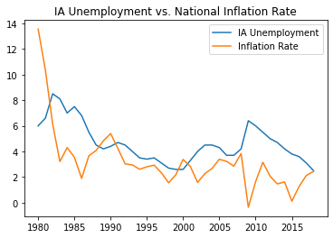

```python
dfiu_IA.plot(kind='line',title='IA Unemployment vs. National Inflation Rate')
plt.show()
```

- unemployment in Iowa does seem to move in tandem with the national inflation rate
- inflation has sharper changes in direction than Iowa unemployment

#### Visualizing United States unemployment and inflation rate in a line plot:

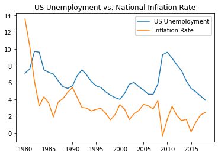

```python
dfiu_us.plot(kind='line', title='US Unemployment vs. National Inflation Rate')
plt.show()
```

- the difference between unemployment and inflation rate is more prominent when assessing national unemployment
- we note that these plots also show that Iowa unemployment tends to be significantly lower than national unemployment
- changes in inflation tend to have a similar impact on national unemployment, but the effects are somewhat lagged

#### Assessing correlation between Iowa unemployment and inflation by creating a scatter plot:

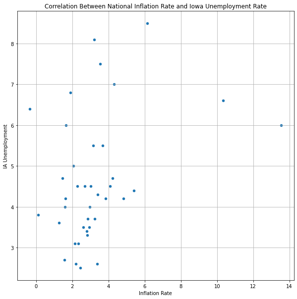

```python
dfiu_IA.plot(kind='scatter', x='Inflation Rate', y='IA Unemployment', title = "Correlation Between National Inflation Rate and Iowa Unemployment Rate", grid=True, figsize=(10,10))
plt.show()
```

#### Obtaining correlation statistic between Iowa unemployment and inflation:

```python
dfiu_IA.corr()
```

|  | IA Unemployment | Inflation Rate |
| --- | --- | --- |
| IA Unemployment | 1.000000 | 0.340411 |
| Inflation Rate | 0.340411 | 1.000000 |

- visually in the scatter plot, there seems to be a pattern of positive correlation between Iowa unemployment and inflation rate
- this positive correlation does not look to be strong in the plot
- after finding the actual correlation statistic, we can determine that there is a level of positive correlation, but it is weak

#### Assessing correlation between United States unemployment and inflation by creating a scatter plot:

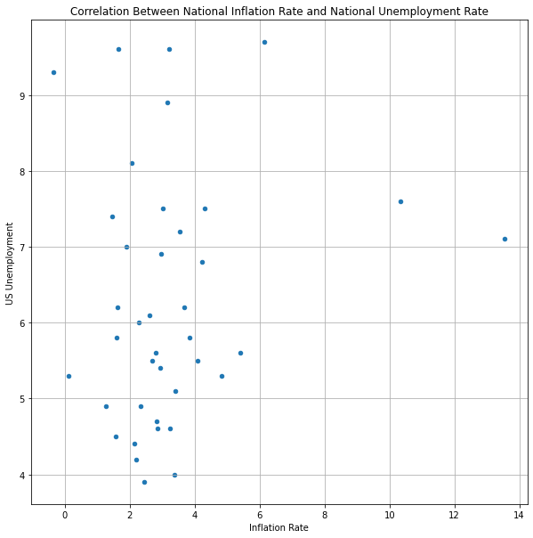

```python
dfiu_us.plot(kind='scatter', x='Inflation Rate', y='US Unemployment', title = "Correlation Between National Inflation Rate and National Unemployment Rate", grid=True, figsize=(10,10))
plt.show()
```

#### Obtaining correlation statistic between United States unemployment and inflation:

```python
Inflation=dfiu_us.corr()
allcorr.append({'Inflation': Inflation[:1]})
dfiu_us.corr()
```

|  | US Unemployment | Inflation Rate |
| --- | --- | --- |
| US Unemployment | 1.000000 | 0.152558 |
| Inflation Rate | 0.152558 | 1.000000 |

- visually in the scatter plot, there does not seem to be a strong correlation between national unemployment and inflation rate
- after finding the actual correlation statistic, we can confirm that the level of correlation between these two variables is weak

```python
allcorr
```

```
[{'US Legis':                      Legislative Control  Unemployment
  Legislative Control                  1.0     -0.647536},
 {'Iowalegis':                      Legislative Control  Unemployment
  Legislative Control                  1.0     -0.507711},
 {'Inflation':                  US Unemployment  Inflation Rate
  US Unemployment              1.0        0.152558}]
```

# Tax Rate Analysis

```python
df6=pd.read_csv("files/taxrates.csv")
df6
```

|  | Year | MFJ Rates | MFJ Brackets | MFS Rates | MFS Brackets | S Rates | S Brackets | HOH Rates | HOH Brackets |
| --- | --- | --- | --- | --- | --- | --- | --- | --- | --- |
| 0 | 2020.0 | 10.0 | 0.0 | 10.0 | 0.0 | 10.0 | 0.0 | 10.0 | 0.0 |
| 1 | 2020.0 | 12.0 | 19750.0 | 12.0 | 9875.0 | 12.0 | 9875.0 | 12.0 | 14100.0 |
| 2 | 2020.0 | 22.0 | 80250.0 | 22.0 | 40125.0 | 22.0 | 40125.0 | 22.0 | 53700.0 |
| 3 | 2020.0 | 24.0 | 171050.0 | 24.0 | 85525.0 | 24.0 | 85525.0 | 24.0 | 85500.0 |
| 4 | 2020.0 | 32.0 | 326600.0 | 32.0 | 163300.0 | 32.0 | 163300.0 | 32.0 | 163300.0 |
| ... | ... | ... | ... | ... | ... | ... | ... | ... | ... |
| 289 | 1980.0 | 59.0 | 85600.0 | 59.0 | 42800.0 | 49.0 | 34100.0 | 59.0 | 60600.0 |
| 290 | 1980.0 | 64.0 | 109400.0 | 64.0 | 54700.0 | 55.0 | 41500.0 | 63.0 | 81800.0 |
| 291 | 1980.0 | 68.0 | 162400.0 | 68.0 | 81200.0 | 63.0 | 55300.0 | 68.0 | 108300.0 |
| 292 | 1980.0 | 70.0 | 215400.0 | 70.0 | 107700.0 | 68.0 | 81800.0 | 70.0 | 161300.0 |
| 293 | 1980.0 | 70.0 | 215400.0 | 70.0 | 107700.0 | 70.0 | 108300.0 | 70.0 | 161300.0 |

294 rows × 9 columns

```python
df7 = df6[(df6['Year'] >= 1980) & (df6['Year'] <=2018)]
df7
```

|  | Year | MFJ Rates | MFJ Brackets | MFS Rates | MFS Brackets | S Rates | S Brackets | HOH Rates | HOH Brackets |
| --- | --- | --- | --- | --- | --- | --- | --- | --- | --- |
| 14 | 2018.0 | 10.0 | 0.0 | 10.0 | 0.0 | 10.0 | 0.0 | 10.0 | 0.0 |
| 15 | 2018.0 | 12.0 | 19050.0 | 12.0 | 9525.0 | 12.0 | 9525.0 | 12.0 | 13600.0 |
| 16 | 2018.0 | 22.0 | 77400.0 | 22.0 | 38700.0 | 22.0 | 38700.0 | 22.0 | 51800.0 |
| 17 | 2018.0 | 24.0 | 165000.0 | 24.0 | 82500.0 | 24.0 | 82500.0 | 24.0 | 82500.0 |
| 18 | 2018.0 | 32.0 | 315000.0 | 32.0 | 157500.0 | 32.0 | 157500.0 | 32.0 | 157500.0 |
| ... | ... | ... | ... | ... | ... | ... | ... | ... | ... |
| 289 | 1980.0 | 59.0 | 85600.0 | 59.0 | 42800.0 | 49.0 | 34100.0 | 59.0 | 60600.0 |
| 290 | 1980.0 | 64.0 | 109400.0 | 64.0 | 54700.0 | 55.0 | 41500.0 | 63.0 | 81800.0 |
| 291 | 1980.0 | 68.0 | 162400.0 | 68.0 | 81200.0 | 63.0 | 55300.0 | 68.0 | 108300.0 |
| 292 | 1980.0 | 70.0 | 215400.0 | 70.0 | 107700.0 | 68.0 | 81800.0 | 70.0 | 161300.0 |
| 293 | 1980.0 | 70.0 | 215400.0 | 70.0 | 107700.0 | 70.0 | 108300.0 | 70.0 | 161300.0 |

280 rows × 9 columns

Divided filiers into their own tables.

MFJ = Married Filing Joint MFS = Married Filing Single S = Single HOH = Head of Household

```python
MFJ = df7[['Year', 'MFJ Rates', 'MFJ Brackets']].copy()
MFJ
```

|  | Year | MFJ Rates | MFJ Brackets |
| --- | --- | --- | --- |
| 14 | 2018.0 | 10.0 | 0.0 |
| 15 | 2018.0 | 12.0 | 19050.0 |
| 16 | 2018.0 | 22.0 | 77400.0 |
| 17 | 2018.0 | 24.0 | 165000.0 |
| 18 | 2018.0 | 32.0 | 315000.0 |
| ... | ... | ... | ... |
| 289 | 1980.0 | 59.0 | 85600.0 |
| 290 | 1980.0 | 64.0 | 109400.0 |
| 291 | 1980.0 | 68.0 | 162400.0 |
| 292 | 1980.0 | 70.0 | 215400.0 |
| 293 | 1980.0 | 70.0 | 215400.0 |

280 rows × 3 columns

```python
MFJ['MFJ Rates'] = pd.to_numeric(MFJ['MFJ Rates'], errors='coerce')
p1 = MFJ.groupby('Year')['MFJ Rates'].mean()
p1
```

```
Year
1980.0    39.235294
1981.0    39.235294
1982.0    28.714286
1983.0    26.500000
1984.0    28.312500
1985.0    28.312500
1986.0    28.312500
1987.0    25.500000
1988.0    21.500000
1989.0    21.500000
1990.0    21.500000
1991.0    24.666667
1992.0    24.666667
1993.0    29.920000
1994.0    29.920000
1995.0    29.920000
1996.0    29.920000
1997.0    29.920000
1998.0    29.920000
1999.0    29.920000
2000.0    29.920000
2001.0    29.520000
2002.0    25.933333
2003.0    24.333333
2004.0    24.333333
2005.0    24.333333
2006.0    24.333333
2007.0    24.333333
2008.0    24.333333
2009.0    24.333333
2010.0    24.333333
2011.0    24.333333
2012.0    24.333333
2013.0    26.514286
2014.0    26.514286
2015.0    26.514286
2016.0    26.514286
2017.0    26.514286
2018.0    24.571429
Name: MFJ Rates, dtype: float64
```

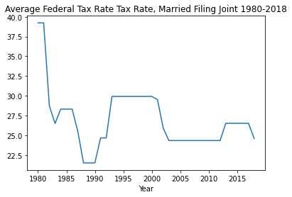

```python
p1.plot(kind="line", legend=False, title="Average Federal Tax Rate Tax Rate, Married Filing Joint 1980-2018")
plt.show()
```

```python
MFS = df7[['Year', 'MFS Rates', 'MFS Brackets']].copy()
MFS
```

|  | Year | MFS Rates | MFS Brackets |
| --- | --- | --- | --- |
| 14 | 2018.0 | 10.0 | 0.0 |
| 15 | 2018.0 | 12.0 | 9525.0 |
| 16 | 2018.0 | 22.0 | 38700.0 |
| 17 | 2018.0 | 24.0 | 82500.0 |
| 18 | 2018.0 | 32.0 | 157500.0 |
| ... | ... | ... | ... |
| 289 | 1980.0 | 59.0 | 42800.0 |
| 290 | 1980.0 | 64.0 | 54700.0 |
| 291 | 1980.0 | 68.0 | 81200.0 |
| 292 | 1980.0 | 70.0 | 107700.0 |
| 293 | 1980.0 | 70.0 | 107700.0 |

280 rows × 3 columns

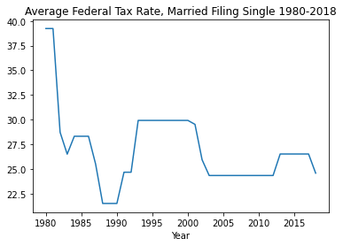

```python
MFS['MFS Rates'] = pd.to_numeric(MFS['MFS Rates'], errors='coerce')
p2 = MFS.groupby('Year')['MFS Rates'].mean()
p2.plot(kind="line", legend=False, title="Average Federal Tax Rate, Married Filing Single 1980-2018")
plt.show()
```

```python
S = df7[['Year', 'S Rates', 'S Brackets']].copy()
S
```

|  | Year | S Rates | S Brackets |
| --- | --- | --- | --- |
| 14 | 2018.0 | 10.0 | 0.0 |
| 15 | 2018.0 | 12.0 | 9525.0 |
| 16 | 2018.0 | 22.0 | 38700.0 |
| 17 | 2018.0 | 24.0 | 82500.0 |
| 18 | 2018.0 | 32.0 | 157500.0 |
| ... | ... | ... | ... |
| 289 | 1980.0 | 49.0 | 34100.0 |
| 290 | 1980.0 | 55.0 | 41500.0 |
| 291 | 1980.0 | 63.0 | 55300.0 |
| 292 | 1980.0 | 68.0 | 81800.0 |
| 293 | 1980.0 | 70.0 | 108300.0 |

280 rows × 3 columns

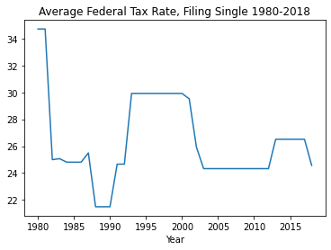

```python
S['S Rates'] = pd.to_numeric(S['S Rates'], errors='coerce')
p3 = S.groupby('Year')['S Rates'].mean()
p3.plot(kind="line", legend=False, title="Average Federal Tax Rate, Filing Single 1980-2018")
plt.show()
```

```python
HOH = df7[['Year', 'HOH Rates', 'HOH Brackets']].copy()
HOH
```

|  | Year | HOH Rates | HOH Brackets |
| --- | --- | --- | --- |
| 14 | 2018.0 | 10.0 | 0.0 |
| 15 | 2018.0 | 12.0 | 13600.0 |
| 16 | 2018.0 | 22.0 | 51800.0 |
| 17 | 2018.0 | 24.0 | 82500.0 |
| 18 | 2018.0 | 32.0 | 157500.0 |
| ... | ... | ... | ... |
| 289 | 1980.0 | 59.0 | 60600.0 |
| 290 | 1980.0 | 63.0 | 81800.0 |
| 291 | 1980.0 | 68.0 | 108300.0 |
| 292 | 1980.0 | 70.0 | 161300.0 |
| 293 | 1980.0 | 70.0 | 161300.0 |

280 rows × 3 columns

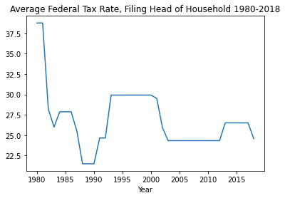

```python
HOH['HOH Rates'] = pd.to_numeric(HOH['HOH Rates'], errors='coerce')
p4 = HOH.groupby('Year')['HOH Rates'].mean()
p4.plot(kind="line", legend=False, title="Average Federal Tax Rate, Filing Head of Household 1980-2018")
plt.show()
```

ANALYSIS - Unemployment file introduced to make comparisons betweent tax rate and unemployment rate

```python
dfu=pd.read_csv("files/stateunemp.csv")
dfu
```

|  | Area | 1980 | 1981 | 1982 | 1983 | 1984 | 1985 | 1986 | 1987 | 1988 | ... | 2009 | 2010 | 2011 | 2012 | 2013 | 2014 | 2015 | 2016 | 2017 | 2018 |
| --- | --- | --- | --- | --- | --- | --- | --- | --- | --- | --- | --- | --- | --- | --- | --- | --- | --- | --- | --- | --- | --- |
| 0 | United States | 7.1 | 7.6 | 9.7 | 9.6 | 7.5 | 7.2 | 7.0 | 6.2 | 5.5 | ... | 9.3 | 9.6 | 8.9 | 8.1 | 7.4 | 6.2 | 5.3 | 4.9 | 4.4 | 3.9 |
| 1 | Alabama | 8.9 | 10.6 | 14.1 | 13.8 | 11.0 | 9.2 | 9.7 | 8.1 | 7.2 | ... | 11.0 | 10.5 | 9.6 | 8.0 | 7.2 | 6.8 | 6.1 | 5.8 | 4.4 | 3.9 |
| 2 | Alaska | 9.6 | 9.4 | 9.9 | 9.9 | 9.8 | 9.7 | 10.9 | 10.3 | 8.8 | ... | 7.7 | 7.9 | 7.6 | 7.1 | 7.0 | 6.9 | 6.5 | 6.9 | 7.0 | 6.6 |
| 3 | Arizona | 6.6 | 6.2 | 10.1 | 8.8 | 5.2 | 6.3 | 6.9 | 6.5 | 6.4 | ... | 9.9 | 10.4 | 9.5 | 8.3 | 7.7 | 6.8 | 6.1 | 5.4 | 4.9 | 4.8 |
| 4 | Arkansas | 7.6 | 8.7 | 9.9 | 9.9 | 8.7 | 8.7 | 8.6 | 8.1 | 7.6 | ... | 7.8 | 8.2 | 8.3 | 7.6 | 7.2 | 6.0 | 5.0 | 4.0 | 3.7 | 3.7 |
| 5 | California | 6.8 | 7.4 | 10.0 | 9.8 | 7.8 | 7.2 | 6.7 | 5.8 | 5.3 | ... | 11.2 | 12.2 | 11.7 | 10.4 | 8.9 | 7.5 | 6.2 | 5.5 | 4.8 | 4.2 |
| 6 | Colorado | 5.8 | 5.7 | 7.3 | 7.1 | 5.4 | 6.1 | 7.5 | 7.5 | 6.5 | ... | 7.3 | 8.7 | 8.4 | 7.9 | 6.9 | 5.0 | 3.9 | 3.2 | 2.7 | 3.3 |
| 7 | Connecticut | 5.8 | 6.2 | 6.9 | 6.0 | 4.7 | 4.7 | 3.8 | 3.4 | 3.0 | ... | 7.9 | 9.1 | 8.8 | 8.3 | 7.8 | 6.6 | 5.7 | 5.1 | 4.7 | 4.1 |
| 8 | Delaware | 7.6 | 7.8 | 8.4 | 7.7 | 6.3 | 5.1 | 4.3 | 3.1 | 3.1 | ... | 8.3 | 8.4 | 7.5 | 7.2 | 6.7 | 5.7 | 4.9 | 4.5 | 4.5 | 3.8 |
| 9 | District of Columbia | 7.4 | 8.9 | 10.4 | 11.2 | 9.1 | 8.1 | 7.5 | 6.3 | 5.0 | ... | 9.3 | 9.4 | 10.2 | 9.0 | 8.5 | 7.8 | 6.9 | 6.1 | 6.1 | 5.6 |
| 10 | Florida | 6.1 | 6.7 | 8.4 | 8.5 | 6.4 | 6.0 | 5.8 | 5.3 | 5.1 | ... | 10.4 | 11.1 | 10.0 | 8.5 | 7.2 | 6.3 | 5.5 | 4.8 | 4.2 | 3.6 |
| 11 | Georgia | 6.3 | 6.4 | 7.8 | 7.7 | 6.1 | 6.4 | 6.0 | 5.7 | 5.7 | ... | 9.9 | 10.5 | 10.2 | 9.2 | 8.2 | 7.1 | 6.0 | 5.4 | 4.7 | 3.9 |
| 12 | Hawaii | 5.0 | 5.4 | 6.3 | 6.2 | 5.7 | 5.4 | 4.8 | 3.8 | 3.2 | ... | 7.2 | 6.9 | 6.8 | 6.0 | 4.9 | 4.4 | 3.6 | 3.0 | 2.4 | 2.4 |
| 13 | Idaho | 7.5 | 7.7 | 9.9 | 8.9 | 7.3 | 7.9 | 8.4 | 7.6 | 6.0 | ... | 8.8 | 9.0 | 8.3 | 7.2 | 6.1 | 4.8 | 4.2 | 3.8 | 3.2 | 2.8 |
| 14 | Illinois | 8.2 | 8.5 | 11.4 | 11.8 | 9.0 | 9.1 | 8.3 | 7.4 | 6.7 | ... | 10.2 | 10.4 | 9.7 | 9.0 | 9.0 | 7.1 | 6.0 | 5.8 | 4.9 | 4.3 |
| 15 | Indiana | 9.6 | 9.9 | 12.0 | 11.2 | 8.6 | 7.8 | 6.9 | 6.2 | 5.2 | ... | 10.3 | 10.4 | 9.1 | 8.3 | 7.7 | 6.0 | 4.8 | 4.4 | 3.6 | 3.4 |
| 16 | Iowa | 6.0 | 6.6 | 8.5 | 8.1 | 7.0 | 7.5 | 6.8 | 5.5 | 4.5 | ... | 6.4 | 6.0 | 5.5 | 5.0 | 4.7 | 4.2 | 3.8 | 3.6 | 3.1 | 2.5 |
| 17 | Kansas | 4.4 | 4.3 | 6.3 | 5.9 | 4.9 | 5.1 | 5.3 | 4.8 | 4.5 | ... | 6.9 | 7.1 | 6.5 | 5.7 | 5.3 | 4.5 | 4.2 | 4.0 | 3.7 | 3.4 |
| 18 | Kentucky | 8.0 | 8.6 | 10.8 | 11.4 | 9.3 | 9.2 | 9.4 | 8.5 | 7.6 | ... | 10.3 | 10.2 | 9.4 | 8.2 | 8.0 | 6.5 | 5.3 | 5.1 | 4.9 | 4.3 |
| 19 | Louisiana | 6.9 | 8.4 | 10.3 | 11.5 | 10.1 | 11.6 | 12.8 | 12.1 | 10.8 | ... | 6.8 | 8.0 | 7.8 | 7.1 | 6.7 | 6.4 | 6.3 | 6.1 | 5.1 | 4.9 |
| 20 | Maine | 7.6 | 7.4 | 8.4 | 8.3 | 6.2 | 5.5 | 5.3 | 4.4 | 3.6 | ... | 8.1 | 8.1 | 7.9 | 7.5 | 6.6 | 5.6 | 4.4 | 3.8 | 3.4 | 3.4 |
| 21 | Maryland | 6.6 | 7.3 | 8.3 | 7.0 | 5.4 | 4.6 | 4.6 | 4.4 | 4.3 | ... | 7.0 | 7.7 | 7.2 | 7.0 | 6.6 | 5.8 | 5.1 | 4.5 | 4.3 | 3.9 |
| 22 | Massachusetts | 5.6 | 6.5 | 7.7 | 6.8 | 4.8 | 4.0 | 3.9 | 3.2 | 3.3 | ... | 8.1 | 8.3 | 7.3 | 6.7 | 6.7 | 5.7 | 4.8 | 3.9 | 3.8 | 3.3 |
| 23 | Michigan | 12.3 | 12.4 | 15.4 | 14.4 | 11.2 | 10.0 | 8.8 | 8.3 | 7.5 | ... | 13.7 | 12.6 | 10.4 | 9.1 | 8.8 | 7.2 | 5.4 | 5.0 | 4.6 | 4.1 |
| 24 | Minnesota | 5.8 | 5.8 | 7.9 | 8.0 | 6.3 | 6.0 | 5.5 | 5.1 | 4.3 | ... | 7.8 | 7.4 | 6.5 | 5.6 | 5.0 | 4.2 | 3.7 | 3.9 | 3.4 | 2.9 |
| 25 | Mississippi | 7.4 | 8.5 | 11.1 | 12.1 | 10.5 | 10.4 | 11.4 | 10.0 | 8.4 | ... | 9.5 | 10.4 | 10.0 | 9.0 | 8.5 | 7.5 | 6.4 | 5.8 | 5.1 | 4.8 |
| 26 | Missouri | 7.2 | 7.6 | 9.2 | 9.9 | 7.2 | 6.5 | 6.2 | 6.3 | 5.7 | ... | 9.3 | 9.6 | 8.5 | 6.9 | 6.7 | 6.1 | 5.0 | 4.6 | 3.8 | 3.2 |
| 27 | Montana | 6.1 | 6.8 | 8.5 | 8.6 | 7.6 | 7.7 | 7.9 | 7.4 | 6.6 | ... | 6.8 | 7.3 | 6.9 | 6.0 | 5.4 | 4.7 | 4.2 | 4.1 | 3.9 | 3.7 |
| 28 | Nebraska | 3.9 | 4.2 | 5.6 | 5.6 | 4.5 | 5.2 | 5.0 | 4.4 | 3.6 | ... | 4.6 | 4.6 | 4.4 | 4.0 | 3.8 | 3.3 | 3.0 | 3.1 | 2.9 | 2.8 |
| 29 | Nevada | 6.2 | 7.2 | 9.9 | 9.6 | 7.9 | 7.7 | 6.2 | 6.1 | 5.2 | ... | 11.3 | 13.5 | 13.0 | 11.2 | 9.6 | 7.9 | 6.8 | 5.7 | 5.1 | 4.6 |
| 30 | New Hampshire | 4.5 | 5.2 | 6.8 | 5.5 | 4.3 | 3.7 | 2.8 | 2.3 | 2.4 | ... | 6.2 | 5.8 | 5.4 | 5.5 | 5.1 | 4.3 | 3.4 | 2.9 | 2.7 | 2.5 |
| 31 | New Jersey | 7.2 | 7.4 | 8.7 | 8.0 | 6.2 | 5.6 | 5.0 | 4.1 | 3.8 | ... | 9.1 | 9.5 | 9.3 | 9.3 | 8.2 | 6.8 | 5.8 | 5.0 | 4.6 | 4.1 |
| 32 | New Mexico | 7.6 | 7.3 | 9.2 | 9.7 | 7.8 | 8.3 | 9.3 | 8.7 | 7.5 | ... | 7.5 | 8.1 | 7.5 | 7.1 | 6.9 | 6.7 | 6.5 | 6.6 | 5.9 | 4.9 |
| 33 | New York | 7.5 | 7.6 | 8.5 | 8.7 | 7.2 | 6.6 | 6.2 | 4.9 | 4.3 | ... | 8.3 | 8.6 | 8.3 | 8.5 | 7.7 | 6.3 | 5.3 | 4.9 | 4.7 | 4.1 |
| 34 | North Carolina | 6.4 | 6.5 | 9.2 | 9.0 | 6.7 | 5.6 | 5.3 | 4.5 | 3.6 | ... | 10.6 | 10.9 | 10.3 | 9.3 | 8.0 | 6.3 | 5.7 | 5.1 | 4.5 | 3.9 |
| 35 | North Dakota | 4.9 | 4.8 | 5.6 | 5.7 | 5.3 | 5.7 | 5.9 | 5.0 | 4.7 | ... | 4.1 | 3.8 | 3.5 | 3.1 | 2.9 | 2.7 | 2.8 | 3.1 | 2.7 | 2.6 |
| 36 | Ohio | 8.4 | 9.4 | 12.7 | 12.4 | 9.5 | 8.9 | 8.3 | 7.1 | 6.0 | ... | 10.3 | 10.3 | 8.8 | 7.4 | 7.5 | 5.8 | 4.9 | 5.0 | 5.0 | 4.6 |
| 37 | Oklahoma | 4.4 | 3.6 | 6.0 | 8.4 | 7.1 | 7.2 | 8.2 | 7.3 | 6.4 | ... | 6.4 | 6.8 | 5.9 | 5.2 | 5.3 | 4.5 | 4.4 | 4.8 | 4.2 | 3.4 |
| 38 | Oregon | 8.5 | 9.8 | 11.5 | 10.8 | 9.4 | 8.8 | 8.0 | 6.3 | 5.8 | ... | 11.3 | 10.6 | 9.5 | 8.8 | 7.9 | 6.8 | 5.6 | 4.8 | 4.1 | 4.2 |
| 39 | Pennsylvania | 8.0 | 8.4 | 11.2 | 11.5 | 9.1 | 8.0 | 6.9 | 5.6 | 5.0 | ... | 8.0 | 8.5 | 7.9 | 7.8 | 7.4 | 5.9 | 5.3 | 5.4 | 4.9 | 4.3 |
| 40 | Rhode Island | 7.2 | 7.8 | 9.7 | 8.3 | 5.5 | 4.6 | 4.1 | 3.6 | 3.1 | ... | 11.0 | 11.2 | 11.0 | 10.4 | 9.3 | 7.7 | 6.0 | 5.2 | 4.4 | 4.1 |
| 41 | South Carolina | 6.7 | 8.1 | 11.1 | 9.9 | 6.9 | 6.9 | 6.4 | 5.5 | 4.7 | ... | 11.2 | 11.2 | 10.6 | 9.2 | 7.6 | 6.5 | 6.0 | 5.0 | 4.3 | 3.4 |
| 42 | South Dakota | 4.8 | 5.0 | 5.5 | 5.2 | 4.4 | 4.8 | 4.6 | 4.2 | 4.1 | ... | 4.9 | 5.0 | 4.7 | 4.3 | 3.8 | 3.4 | 3.1 | 3.0 | 3.2 | 3.0 |
| 43 | Tennessee | 7.4 | 9.0 | 11.7 | 11.5 | 8.5 | 7.9 | 7.9 | 6.6 | 5.8 | ... | 10.5 | 9.7 | 9.0 | 7.8 | 7.8 | 6.6 | 5.6 | 4.7 | 3.8 | 3.5 |
| 44 | Texas | 5.1 | 5.3 | 6.9 | 7.9 | 6.1 | 7.0 | 8.8 | 8.4 | 7.3 | ... | 7.6 | 8.1 | 7.8 | 6.7 | 6.3 | 5.1 | 4.4 | 4.6 | 4.3 | 3.9 |
| 45 | Utah | 6.2 | 6.6 | 8.2 | 8.7 | 6.5 | 6.0 | 6.1 | 6.2 | 5.0 | ... | 7.3 | 7.8 | 6.7 | 5.4 | 4.6 | 3.8 | 3.6 | 3.4 | 3.3 | 3.1 |
| 46 | Vermont | 6.2 | 5.8 | 7.0 | 6.4 | 5.1 | 4.8 | 4.3 | 3.6 | 3.0 | ... | 6.6 | 6.1 | 5.5 | 5.0 | 4.4 | 3.9 | 3.6 | 3.2 | 3.0 | 2.7 |
| 47 | Virginia | 5.2 | 6.0 | 7.4 | 6.4 | 5.1 | 5.5 | 5.0 | 4.3 | 3.9 | ... | 6.7 | 7.1 | 6.6 | 6.1 | 5.7 | 5.2 | 4.5 | 4.1 | 3.7 | 3.0 |
| 48 | Washington | 8.1 | 9.6 | 11.9 | 11.1 | 9.3 | 8.4 | 8.1 | 7.3 | 6.3 | ... | 9.2 | 10.0 | 9.3 | 8.1 | 7.0 | 6.1 | 5.6 | 5.3 | 4.7 | 4.5 |
| 49 | West Virginia | 9.5 | 10.6 | 14.0 | 17.8 | 14.8 | 13.1 | 11.8 | 10.8 | 9.8 | ... | 7.7 | 8.7 | 8.1 | 7.5 | 6.8 | 6.6 | 6.7 | 6.1 | 5.2 | 5.3 |
| 50 | Wisconsin | 7.2 | 8.0 | 10.5 | 10.2 | 7.4 | 7.2 | 7.0 | 5.9 | 4.4 | ... | 8.6 | 8.7 | 7.8 | 7.0 | 6.7 | 5.4 | 4.6 | 4.0 | 3.3 | 3.0 |
| 51 | Wyoming | 3.9 | 4.1 | 6.2 | 8.2 | 6.3 | 6.9 | 8.9 | 8.0 | 6.5 | ... | 6.3 | 6.4 | 5.8 | 5.3 | 4.7 | 4.1 | 4.3 | 5.3 | 4.2 | 4.1 |

52 rows × 40 columns

```python
dfu1=dfu.copy()
dfu1=dfu1.mean() #Average US unemployment per year
dfu1
```

```
1980    6.823077
1981    7.319231
1982    9.228846
1983    9.165385
1984    7.307692
1985    7.065385
1986    6.944231
1987    6.192308
1988    5.453846
1989    5.132692
1990    5.436538
1991    6.473077
1992    6.867308
1993    6.307692
1994    5.634615
```

[output cut: 25 more lines]

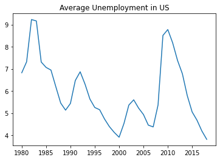

```python
dfu1=dfu.copy()
dfu1=dfu1.mean() #Average US unemployment per year
dfu1

dfu1.plot(kind="line", legend=False, title="Average Unemployment in US")
plt.show()
```

```python
dfiowau=dfu.iloc[16] #Select only Iowa unemployment data
dfiowau=dfiowau[1:]
dfiowau
```

```
1980    6.0
1981    6.6
1982    8.5
1983    8.1
1984    7.0
1985    7.5
1986    6.8
1987    5.5
1988    4.5
1989    4.2
1990    4.4
1991    4.7
1992    4.5
1993    4.0
1994    3.5
```

[output cut: 25 more lines]

```python
year=dfiowau.index
df1 = pd.DataFrame(list(zip(p1 , dfu1)),
                  index = year,
                  columns = ['Average Federal Tax Rates','Average IA Unemployment Rates'])
df1
```

|  | Average Federal Tax Rates | Average IA Unemployment Rates |
| --- | --- | --- |
| 1980 | 39.235294 | 6.823077 |
| 1981 | 39.235294 | 7.319231 |
| 1982 | 28.714286 | 9.228846 |
| 1983 | 26.500000 | 9.165385 |
| 1984 | 28.312500 | 7.307692 |
| 1985 | 28.312500 | 7.065385 |
| 1986 | 28.312500 | 6.944231 |
| 1987 | 25.500000 | 6.192308 |
| 1988 | 21.500000 | 5.453846 |
| 1989 | 21.500000 | 5.132692 |
| 1990 | 21.500000 | 5.436538 |
| 1991 | 24.666667 | 6.473077 |
| 1992 | 24.666667 | 6.867308 |
| 1993 | 29.920000 | 6.307692 |
| 1994 | 29.920000 | 5.634615 |
| 1995 | 29.920000 | 5.253846 |
| 1996 | 29.920000 | 5.151923 |
| 1997 | 29.920000 | 4.734615 |
| 1998 | 29.920000 | 4.390385 |
| 1999 | 29.920000 | 4.126923 |
| 2000 | 29.920000 | 3.909615 |
| 2001 | 29.520000 | 4.532692 |
| 2002 | 25.933333 | 5.363462 |
| 2003 | 24.333333 | 5.600000 |
| 2004 | 24.333333 | 5.226923 |
| 2005 | 24.333333 | 4.936538 |
| 2006 | 24.333333 | 4.455769 |
| 2007 | 24.333333 | 4.375000 |
| 2008 | 24.333333 | 5.365385 |
| 2009 | 24.333333 | 8.509615 |
| 2010 | 24.333333 | 8.776923 |
| 2011 | 24.333333 | 8.176923 |
| 2012 | 24.333333 | 7.382692 |
| 2013 | 26.514286 | 6.776923 |
| 2014 | 26.514286 | 5.790385 |
| 2015 | 26.514286 | 5.053846 |
| 2016 | 26.514286 | 4.678846 |
| 2017 | 26.514286 | 4.192308 |
| 2018 | 24.571429 | 3.813462 |

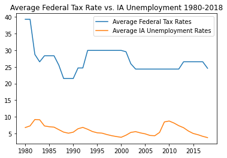

```python
df1.plot(kind='line',title='Average Federal Tax Rate vs. IA Unemployment 1980-2018')
plt.show()
```

```python
corrMatrix = df1.corr()
allcorr.append({'Tax Rates': corrMatrix[:1]})
corrMatrix
```

|  | Average Federal Tax Rates | Average IA Unemployment Rates |
| --- | --- | --- |
| Average Federal Tax Rates | 1.000000 | 0.062782 |
| Average IA Unemployment Rates | 0.062782 | 1.000000 |

# Population Analysis

```python
county_df=pd.read_csv("files/county_pop.csv")
state_df=pd.read_csv("files/state_pop.csv")
US_df=pd.read_csv("files/US_pop.csv")
```

ANALYSIS

The national unemployment rate had an overall downward trend until the '08 recession. Eventually the unemployment rate came back down the where it had been pre-housing crash, with Covid looming in the future.

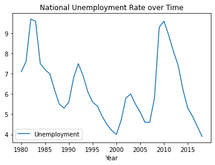

```python
US_df.plot(kind="line", x="Year", y="Unemployment", title="National Unemployment Rate over Time")
```

This scatter plot shows that there is practically no relationship between the unemployment rate of a state and the state's population. The correlation coefficient backs this up, as it is very close to zero.

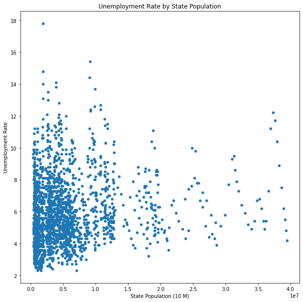

```python
state_df.plot(kind="scatter", x="Population", y="Unemployment", title="Unemployment Rate by State Population", xlabel="State Population (10 M)", ylabel="Unemployment Rate", figsize=(10,10))
```

```python
state_df.Population.corr(state_df.Unemployment)
```

```
0.12702747727033867
```

This scatter plot, and correlation coefficient, shows that the relationship between unemployment rate and population behaves similarly at the county level in Iowa as it did at the state level, in that there is very little relationship.

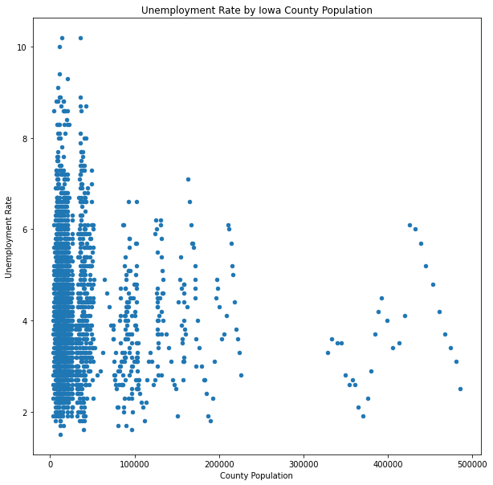

```python
county_df.plot(kind="scatter", x="Population", y="Unemployment", title="Unemployment Rate by Iowa County Population", xlabel="County Population", ylabel="Unemployment Rate", figsize=(10,10))
```

```python
county_df.Population.corr(county_df.Unemployment)
```

```
-0.04030023533689861
```

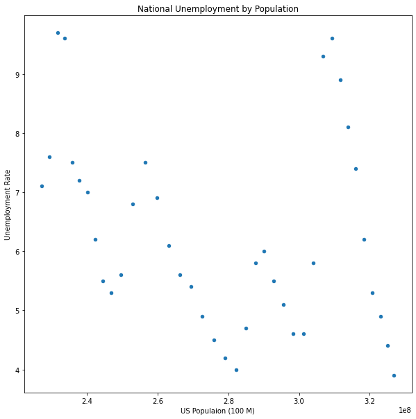

```python
US_df.plot(kind="scatter", x="Population", y="Unemployment", title="National Unemployment by Population", xlabel="US Populaion (100 M)", ylabel="Unemployment Rate", figsize=(10,10))
```

```python
US_df.Population.corr(US_df.Unemployment)
```

```
-0.2748416395732595
```

```python
#Calculates the average unemployment rate by state
state_avgs=state_df.groupby("State").Unemployment.mean()
state_avgs=state_avgs.sort_values(ascending=False)
```

This bar chart shows that the states with the highest average unemployment rates are West Virginia, Michigan and Alaska; while the states with the lowest average unemployment rates are Nebraska and the Dakotas.

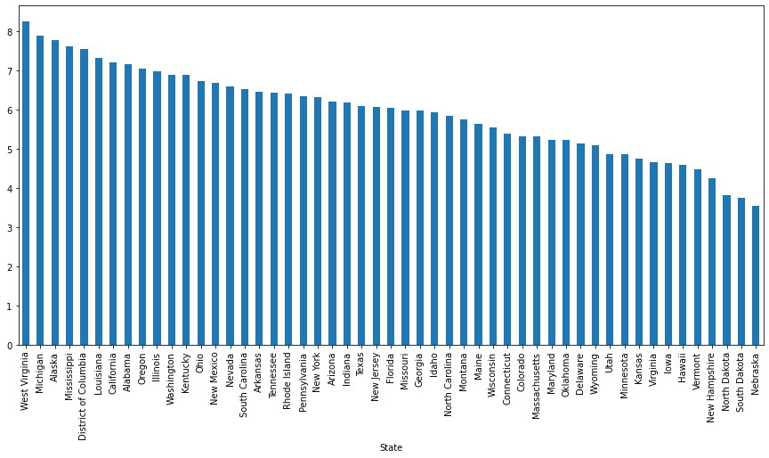

```python
state_avgs.plot(kind="bar", figsize=(15,7))
```

```python
#calculates the unemployment rate by Iowan county
county_avgs=county_df.groupby("County").Unemployment.mean().sort_values(ascending=False)
county_avgs
```

```
County
Lee          6.379310
Appanoose    5.524138
Wapello      5.506897
Clayton      5.362069
Chickasaw    5.313793
               ...
Dallas       2.979310
Story        2.924138
Johnson      2.886207
Sioux        2.820690
Lyon         2.603448
Name: Unemployment, Length: 99, dtype: float64
```

This bar chart shows that the counties with the highest average unemployment rate are Lee, Appanoose and Wapello; while the counties with the lowest average unemployment rate are Lyon, Sioux and Johnson.

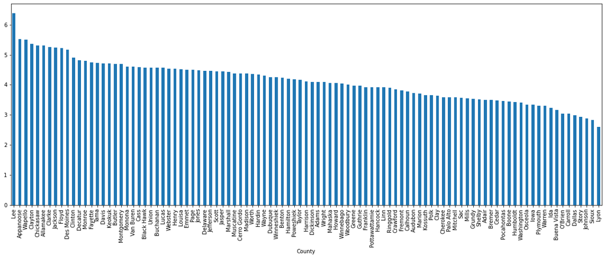

```python
county_avgs.plot(kind="bar", figsize=(20,7))
```

# COVID Analysis

```python
unemp=pd.read_csv('files/iowaunempmonthly.csv')
unemp
#reading monthly unemployment rate by county file
```

|  | AREANAME | YEAR | MONTH | UNEMPRATE |
| --- | --- | --- | --- | --- |
| 0 | Iowa | 2021 | October | 2.9 |
| 1 | Iowa | 2021 | October | 3.9 |
| 2 | Iowa | 2021 | September | 4.0 |
| 3 | Iowa | 2021 | September | 2.9 |
| 4 | Iowa | 2021 | August | 3.8 |
| ... | ... | ... | ... | ... |
| 604 | Adair County | 2015 | February | 4.5 |
| 605 | Adair County | 2015 | January | 4.9 |
| 606 | Adair County | 2014 | December | 3.5 |
| 607 | Adair County | 2014 | November | 3.3 |
| 608 | Adair County | 2014 | October | 3.2 |

609 rows × 4 columns

```python
unemp2020 = unemp.loc[unemp['YEAR'] == 2020]
unemp2020
```

|  | AREANAME | YEAR | MONTH | UNEMPRATE |
| --- | --- | --- | --- | --- |
| 20 | Iowa | 2020 | December | 4.1 |
| 21 | Iowa | 2020 | December | 3.7 |
| 22 | Iowa | 2020 | November | 3.9 |
| 23 | Iowa | 2020 | November | 3.7 |
| 24 | Iowa | 2020 | October | 4.2 |
| 25 | Iowa | 2020 | October | 3.4 |
| 26 | Iowa | 2020 | September | 4.2 |
| 27 | Iowa | 2020 | September | 4.7 |
| 28 | Iowa | 2020 | August | 5.3 |
| 29 | Iowa | 2020 | August | 4.9 |
| 30 | Iowa | 2020 | July | 6.1 |
| 31 | Iowa | 2020 | July | 5.9 |
| 32 | Iowa | 2020 | June | 7.1 |
| 33 | Iowa | 2020 | June | 7.3 |
| 34 | Iowa | 2020 | May | 8.3 |
| 35 | Iowa | 2020 | May | 8.3 |
| 36 | Iowa | 2020 | April | 11.0 |
| 37 | Iowa | 2020 | April | 11.1 |
| 38 | Iowa | 2020 | March | 2.9 |
| 39 | Iowa | 2020 | March | 3.5 |
| 40 | Iowa | 2020 | February | 3.2 |
| 41 | Iowa | 2020 | February | 2.9 |
| 42 | Iowa | 2020 | January | 2.8 |
| 43 | Iowa | 2020 | January | 3.6 |
| 534 | Adair County | 2020 | December | 3.0 |
| 535 | Adair County | 2020 | November | 2.6 |
| 536 | Adair County | 2020 | October | 2.4 |
| 537 | Adair County | 2020 | September | 2.8 |
| 538 | Adair County | 2020 | August | 3.3 |
| 539 | Adair County | 2020 | July | 4.2 |
| 540 | Adair County | 2020 | June | 5.0 |
| 541 | Adair County | 2020 | May | 6.7 |
| 542 | Adair County | 2020 | April | 9.0 |
| 543 | Adair County | 2020 | March | 3.2 |
| 544 | Adair County | 2020 | February | 3.0 |
| 545 | Adair County | 2020 | January | 2.8 |

```python
unempIA20 = unemp2020.loc[unemp['AREANAME'] == 'Iowa']
unempIA20
```

|  | AREANAME | YEAR | MONTH | UNEMPRATE |
| --- | --- | --- | --- | --- |
| 20 | Iowa | 2020 | December | 4.1 |
| 21 | Iowa | 2020 | December | 3.7 |
| 22 | Iowa | 2020 | November | 3.9 |
| 23 | Iowa | 2020 | November | 3.7 |
| 24 | Iowa | 2020 | October | 4.2 |
| 25 | Iowa | 2020 | October | 3.4 |
| 26 | Iowa | 2020 | September | 4.2 |
| 27 | Iowa | 2020 | September | 4.7 |
| 28 | Iowa | 2020 | August | 5.3 |
| 29 | Iowa | 2020 | August | 4.9 |
| 30 | Iowa | 2020 | July | 6.1 |
| 31 | Iowa | 2020 | July | 5.9 |
| 32 | Iowa | 2020 | June | 7.1 |
| 33 | Iowa | 2020 | June | 7.3 |
| 34 | Iowa | 2020 | May | 8.3 |
| 35 | Iowa | 2020 | May | 8.3 |
| 36 | Iowa | 2020 | April | 11.0 |
| 37 | Iowa | 2020 | April | 11.1 |
| 38 | Iowa | 2020 | March | 2.9 |
| 39 | Iowa | 2020 | March | 3.5 |
| 40 | Iowa | 2020 | February | 3.2 |
| 41 | Iowa | 2020 | February | 2.9 |
| 42 | Iowa | 2020 | January | 2.8 |
| 43 | Iowa | 2020 | January | 3.6 |

```python
unempIA20avg = unempIA20.groupby("MONTH")["UNEMPRATE"].mean()
unempIA20avg
```

```
MONTH
April        11.05
August        5.10
December      3.90
February      3.05
January       3.20
July          6.00
June          7.20
March         3.20
May           8.30
November      3.80
October       3.80
September     4.45
Name: UNEMPRATE, dtype: float64
```

```python
unempIA20avg1 = unempIA20avg.drop(labels=['January','February'])
unempIA20avg1
```

```
MONTH
April        11.05
August        5.10
December      3.90
July          6.00
June          7.20
March         3.20
May           8.30
November      3.80
October       3.80
September     4.45
Name: UNEMPRATE, dtype: float64
```

```python
unemp2021 = unemp.loc[unemp['YEAR'] == 2021]
unemp2021
```

|  | AREANAME | YEAR | MONTH | UNEMPRATE |
| --- | --- | --- | --- | --- |
| 0 | Iowa | 2021 | October | 2.9 |
| 1 | Iowa | 2021 | October | 3.9 |
| 2 | Iowa | 2021 | September | 4.0 |
| 3 | Iowa | 2021 | September | 2.9 |
| 4 | Iowa | 2021 | August | 3.8 |
| 5 | Iowa | 2021 | August | 4.1 |
| 6 | Iowa | 2021 | July | 4.0 |
| 7 | Iowa | 2021 | July | 4.1 |
| 8 | Iowa | 2021 | June | 4.7 |
| 9 | Iowa | 2021 | June | 4.0 |
| 10 | Iowa | 2021 | May | 3.9 |
| 11 | Iowa | 2021 | May | 4.1 |
| 12 | Iowa | 2021 | April | 4.0 |
| 13 | Iowa | 2021 | April | 3.8 |
| 14 | Iowa | 2021 | March | 4.5 |
| 15 | Iowa | 2021 | March | 3.7 |
| 16 | Iowa | 2021 | February | 5.0 |
| 17 | Iowa | 2021 | February | 3.7 |
| 18 | Iowa | 2021 | January | 4.8 |
| 19 | Iowa | 2021 | January | 3.6 |
| 524 | Adair County | 2021 | October | 2.1 |
| 525 | Adair County | 2021 | September | 2.3 |
| 526 | Adair County | 2021 | August | 2.8 |
| 527 | Adair County | 2021 | July | 2.7 |
| 528 | Adair County | 2021 | June | 3.1 |
| 529 | Adair County | 2021 | May | 2.9 |
| 530 | Adair County | 2021 | April | 2.6 |
| 531 | Adair County | 2021 | March | 3.2 |
| 532 | Adair County | 2021 | February | 4.6 |
| 533 | Adair County | 2021 | January | 3.6 |

```python
unempIA21 = unemp2021.loc[unemp['AREANAME'] == 'Iowa']
unempIA21
```

|  | AREANAME | YEAR | MONTH | UNEMPRATE |
| --- | --- | --- | --- | --- |
| 0 | Iowa | 2021 | October | 2.9 |
| 1 | Iowa | 2021 | October | 3.9 |
| 2 | Iowa | 2021 | September | 4.0 |
| 3 | Iowa | 2021 | September | 2.9 |
| 4 | Iowa | 2021 | August | 3.8 |
| 5 | Iowa | 2021 | August | 4.1 |
| 6 | Iowa | 2021 | July | 4.0 |
| 7 | Iowa | 2021 | July | 4.1 |
| 8 | Iowa | 2021 | June | 4.7 |
| 9 | Iowa | 2021 | June | 4.0 |
| 10 | Iowa | 2021 | May | 3.9 |
| 11 | Iowa | 2021 | May | 4.1 |
| 12 | Iowa | 2021 | April | 4.0 |
| 13 | Iowa | 2021 | April | 3.8 |
| 14 | Iowa | 2021 | March | 4.5 |
| 15 | Iowa | 2021 | March | 3.7 |
| 16 | Iowa | 2021 | February | 5.0 |
| 17 | Iowa | 2021 | February | 3.7 |
| 18 | Iowa | 2021 | January | 4.8 |
| 19 | Iowa | 2021 | January | 3.6 |

```python
unempIA21avg = unempIA21.groupby("MONTH")["UNEMPRATE"].mean()
unempIA21avg
```

```
MONTH
April        3.90
August       3.95
February     4.35
January      4.20
July         4.05
June         4.35
March        4.10
May          4.00
October      3.40
September    3.45
Name: UNEMPRATE, dtype: float64
```

```python
c19=pd.read_csv('files/covid19.csv')
c19

#reading covid file
```

|  | state | outcome | date | new_results | total_results |
| --- | --- | --- | --- | --- | --- |
| 0 | IA | Negative | 2020/03/01 | 1 | 1 |
| 1 | IA | Negative | 2020/03/02 | 0 | 1 |
| 2 | IA | Negative | 2020/03/03 | 0 | 1 |
| 3 | IA | Negative | 2020/03/04 | 0 | 1 |
| 4 | IA | Negative | 2020/03/05 | 0 | 1 |
| ... | ... | ... | ... | ... | ... |
| 1835 | IA | Negative | 2021/11/19 | 6405 | 4201286 |
| 1836 | IA | Positive | 2021/11/19 | 1113 | 504186 |
| 1837 | IA | Inconclusive | 2021/11/20 | 18 | 12782 |
| 1838 | IA | Negative | 2021/11/20 | 3610 | 4204896 |
| 1839 | IA | Positive | 2021/11/20 | 635 | 504821 |

1840 rows × 5 columns

```python
c19['date'] = pd.to_datetime(c19['date'])
c19['year']=c19.date.map(lambda x: x.strftime('%Y'))
c19['month']=c19.date.map(lambda x: x.strftime('%B'))
c19
```

|  | state | outcome | date | new_results | total_results | year | month |
| --- | --- | --- | --- | --- | --- | --- | --- |
| 0 | IA | Negative | 2020-03-01 | 1 | 1 | 2020 | March |
| 1 | IA | Negative | 2020-03-02 | 0 | 1 | 2020 | March |
| 2 | IA | Negative | 2020-03-03 | 0 | 1 | 2020 | March |
| 3 | IA | Negative | 2020-03-04 | 0 | 1 | 2020 | March |
| 4 | IA | Negative | 2020-03-05 | 0 | 1 | 2020 | March |
| ... | ... | ... | ... | ... | ... | ... | ... |
| 1835 | IA | Negative | 2021-11-19 | 6405 | 4201286 | 2021 | November |
| 1836 | IA | Positive | 2021-11-19 | 1113 | 504186 | 2021 | November |
| 1837 | IA | Inconclusive | 2021-11-20 | 18 | 12782 | 2021 | November |
| 1838 | IA | Negative | 2021-11-20 | 3610 | 4204896 | 2021 | November |
| 1839 | IA | Positive | 2021-11-20 | 635 | 504821 | 2021 | November |

1840 rows × 7 columns

```python
c19['year'] = pd.to_numeric(c19['year'])
```

```python
c19.dtypes
```

```
state                    object
outcome                  object
date             datetime64[ns]
new_results               int64
total_results             int64
year                      int64
month                    object
dtype: object
```

```python
cov20 = c19.loc[c19['year'] == 2020]
cov20
```

|  | state | outcome | date | new_results | total_results | year | month |
| --- | --- | --- | --- | --- | --- | --- | --- |
| 0 | IA | Negative | 2020-03-01 | 1 | 1 | 2020 | March |
| 1 | IA | Negative | 2020-03-02 | 0 | 1 | 2020 | March |
| 2 | IA | Negative | 2020-03-03 | 0 | 1 | 2020 | March |
| 3 | IA | Negative | 2020-03-04 | 0 | 1 | 2020 | March |
| 4 | IA | Negative | 2020-03-05 | 0 | 1 | 2020 | March |
| ... | ... | ... | ... | ... | ... | ... | ... |
| 863 | IA | Negative | 2020-12-30 | 9727 | 2162391 | 2020 | December |
| 864 | IA | Positive | 2020-12-30 | 1565 | 290186 | 2020 | December |
| 865 | IA | Inconclusive | 2020-12-31 | 23 | 6793 | 2020 | December |
| 866 | IA | Negative | 2020-12-31 | 9910 | 2172301 | 2020 | December |
| 867 | IA | Positive | 2020-12-31 | 1813 | 291999 | 2020 | December |

868 rows × 7 columns

```python
cov20pos=cov20[cov20['outcome'] == 'Positive']
cov20pos
```

|  | state | outcome | date | new_results | total_results | year | month |
| --- | --- | --- | --- | --- | --- | --- | --- |
| 13 | IA | Positive | 2020-03-13 | 1 | 1 | 2020 | March |
| 15 | IA | Positive | 2020-03-14 | 0 | 1 | 2020 | March |
| 17 | IA | Positive | 2020-03-15 | 0 | 1 | 2020 | March |
| 19 | IA | Positive | 2020-03-16 | 0 | 1 | 2020 | March |
| 21 | IA | Positive | 2020-03-17 | 0 | 1 | 2020 | March |
| ... | ... | ... | ... | ... | ... | ... | ... |
| 855 | IA | Positive | 2020-12-27 | 639 | 286507 | 2020 | December |
| 858 | IA | Positive | 2020-12-28 | 851 | 287358 | 2020 | December |
| 861 | IA | Positive | 2020-12-29 | 1263 | 288621 | 2020 | December |
| 864 | IA | Positive | 2020-12-30 | 1565 | 290186 | 2020 | December |
| 867 | IA | Positive | 2020-12-31 | 1813 | 291999 | 2020 | December |

294 rows × 7 columns

```python
cov20posSUM = cov20pos.groupby("month")["new_results"].sum()
cov20posSUM
```

```
month
April          6938
August        22800
December      44307
July          19770
June          12580
March            23
May           15992
November     100811
October       42453
September     26325
Name: new_results, dtype: int64
```

```python
cov21 = c19.loc[c19['year'] == 2021]
cov21
```

|  | state | outcome | date | new_results | total_results | year | month |
| --- | --- | --- | --- | --- | --- | --- | --- |
| 868 | IA | Inconclusive | 2021-01-01 | 2 | 6795 | 2021 | January |
| 869 | IA | Negative | 2021-01-01 | 3380 | 2175681 | 2021 | January |
| 870 | IA | Positive | 2021-01-01 | 544 | 292543 | 2021 | January |
| 871 | IA | Inconclusive | 2021-01-02 | 7 | 6802 | 2021 | January |
| 872 | IA | Negative | 2021-01-02 | 5549 | 2181230 | 2021 | January |
| ... | ... | ... | ... | ... | ... | ... | ... |
| 1835 | IA | Negative | 2021-11-19 | 6405 | 4201286 | 2021 | November |
| 1836 | IA | Positive | 2021-11-19 | 1113 | 504186 | 2021 | November |
| 1837 | IA | Inconclusive | 2021-11-20 | 18 | 12782 | 2021 | November |
| 1838 | IA | Negative | 2021-11-20 | 3610 | 4204896 | 2021 | November |
| 1839 | IA | Positive | 2021-11-20 | 635 | 504821 | 2021 | November |

972 rows × 7 columns

```python
cov21pos=cov21[cov21['outcome'] == 'Positive']
cov21pos
```

|  | state | outcome | date | new_results | total_results | year | month |
| --- | --- | --- | --- | --- | --- | --- | --- |
| 870 | IA | Positive | 2021-01-01 | 544 | 292543 | 2021 | January |
| 873 | IA | Positive | 2021-01-02 | 1117 | 293660 | 2021 | January |
| 876 | IA | Positive | 2021-01-03 | 694 | 294354 | 2021 | January |
| 879 | IA | Positive | 2021-01-04 | 1104 | 295458 | 2021 | January |
| 882 | IA | Positive | 2021-01-05 | 2033 | 297491 | 2021 | January |
| ... | ... | ... | ... | ... | ... | ... | ... |
| 1827 | IA | Positive | 2021-11-16 | 1422 | 500033 | 2021 | November |
| 1830 | IA | Positive | 2021-11-17 | 1420 | 501453 | 2021 | November |
| 1833 | IA | Positive | 2021-11-18 | 1620 | 503073 | 2021 | November |
| 1836 | IA | Positive | 2021-11-19 | 1113 | 504186 | 2021 | November |
| 1839 | IA | Positive | 2021-11-20 | 635 | 504821 | 2021 | November |

324 rows × 7 columns

```python
cov21posSUM = cov21pos.groupby("month")["new_results"].sum()
cov21posSUM
```

```
month
April        12322
August       30995
February     14814
January      31366
July          9341
June          2774
March        12990
May           6144
November     22352
October      28624
September    41100
Name: new_results, dtype: int64
```

```python
cov21posSUM1 = cov21posSUM.drop(labels=['November'])
cov21posSUM1
```

```
month
April        12322
August       30995
February     14814
January      31366
July          9341
June          2774
March        12990
May           6144
October      28624
September    41100
Name: new_results, dtype: int64
```

```python
index=["March","April","May","June","July","August","September","October","November","December"]
UEcov20 = pd.DataFrame(list(zip( unempIA20avg1 , cov20posSUM)),
                  index = index,
                  columns = ['Average Unemployment by Month' , 'Total Cases of Covid by Month' ])
UEcov20
#zipped positive results and unemployment together by date string
```

|  | Average Unemployment by Month | Total Cases of Covid by Month |
| --- | --- | --- |
| March | 11.05 | 6938 |
| April | 5.10 | 22800 |
| May | 3.90 | 44307 |
| June | 6.00 | 19770 |
| July | 7.20 | 12580 |
| August | 3.20 | 23 |
| September | 8.30 | 15992 |
| October | 3.80 | 100811 |
| November | 3.80 | 42453 |
| December | 4.45 | 26325 |

```python
index=["January","February","March","April","May","June","July","August","September","October"]
UEcov21 = pd.DataFrame(list(zip( unempIA21avg , cov21posSUM)),
                  index = index,
                  columns = ['Average Unemployment by Month' , 'Total Cases of Covid by Month' ])
UEcov21
```

|  | Average Unemployment by Month | Total Cases of Covid by Month |
| --- | --- | --- |
| January | 3.90 | 12322 |
| February | 3.95 | 30995 |
| March | 4.35 | 14814 |
| April | 4.20 | 31366 |
| May | 4.05 | 9341 |
| June | 4.35 | 2774 |
| July | 4.10 | 12990 |
| August | 4.00 | 6144 |
| September | 3.40 | 22352 |
| October | 3.45 | 28624 |

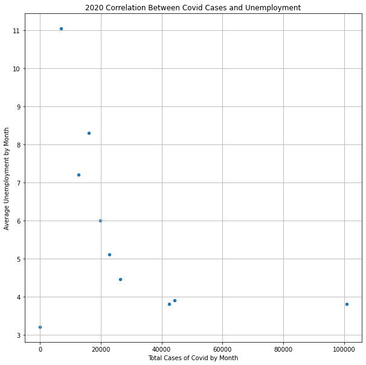

```python
UEcov20.plot(kind='scatter', x='Total Cases of Covid by Month', y='Average Unemployment by Month', title = "2020 Correlation Between Covid Cases and Unemployment", grid=True, figsize=(10,10))
plt.show()
```

```python
covidia20=UEcov20.corr()
allcorr.append({'COVID Iowa': covidia20[:1]})
UEcov20.corr()
```

|  | Average Unemployment by Month | Total Cases of Covid by Month |
| --- | --- | --- |
| Average Unemployment by Month | 1.000000 | -0.445905 |
| Total Cases of Covid by Month | -0.445905 | 1.000000 |

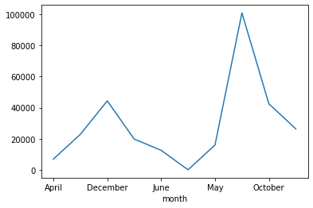

```python
cov20posSUM.plot(kind='line')
```

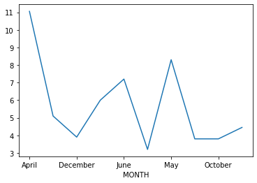

```python
unempIA20avg1.plot(kind='line')
```

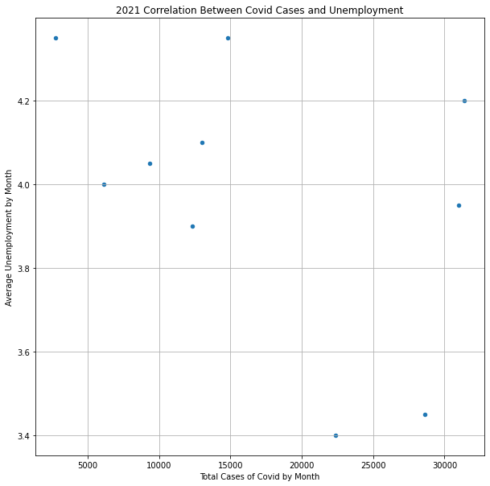

```python
UEcov21.plot(kind='scatter', x='Total Cases of Covid by Month', y='Average Unemployment by Month', title = "2021 Correlation Between Covid Cases and Unemployment", grid=True, figsize=(10,10))
plt.show()
```

```python
covidia21=UEcov21.corr()
allcorr.append({'COVID Iowa 21': covidia21[:1]})
UEcov21.corr()
```

|  | Average Unemployment by Month | Total Cases of Covid by Month |
| --- | --- | --- |
| Average Unemployment by Month | 1.000000 | -0.435399 |
| Total Cases of Covid by Month | -0.435399 | 1.000000 |

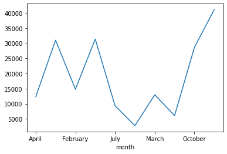

```python
cov21posSUM1.plot(kind='line')
```

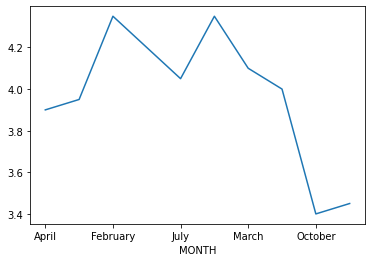

```python
unempIA21avg.plot(kind='line')
```

```python
allcorr
```

```
[{'US Legis':                      Legislative Control  Unemployment
  Legislative Control                  1.0     -0.647536},
 {'Iowalegis':                      Legislative Control  Unemployment
  Legislative Control                  1.0     -0.507711},
 {'Inflation':                  US Unemployment  Inflation Rate
  US Unemployment              1.0        0.152558},
 {'Tax Rates':                            Average Federal Tax Rates  \
  Average Federal Tax Rates                        1.0

                             Average IA Unemployment Rates
  Average Federal Tax Rates                       0.062782  },
 {'COVID Iowa':                                Average Unemployment by Month  \
  Average Unemployment by Month                            1.0

                                 Total Cases of Covid by Month
  Average Unemployment by Month                      -0.445905  },
 {'COVID Iowa 21':                                Average Unemployment by Month  \
  Average Unemployment by Month                            1.0

                                 Total Cases of Covid by Month
  Average Unemployment by Month                      -0.435399  }]
```